# DSC531 Semester Project - Amazon Data Science Books

Florentia Pattidou, Valeria Shirshina, Marios Makrygiannis

2026-11-04

# 0. Libraries and data

```r
library(knitr)      # report generation
library(tidyverse)  # data manipulation and ggplot2 graphics
library(corrplot)   # correlation heatmaps
library(car)        # variance inflation factors (VIF)

# Clear graphics devices and define directory once
graphics.off()
plots_dir <- "plots"

if (!dir.exists(plots_dir)) {
  dir.create(plots_dir, recursive = TRUE)
}

books <- read.csv("data/Amazon_Data_Science_Books.csv")
```

# 1. Data understanding

```r
# 1.2 Check the dimensions of the dataset
print(dim(books))
```

```
## [1] 946  11
```

```r
# 1.3 Display the first six observations
print(head(books))
```

```
##   price pages avg_reviews n_reviews star5 star4 star3 star2 star1      weight
## 1 24.49   272         4.6       184  0.74  0.18  0.05  0.02  0.01 12.5 ounces
## 2 26.00   301         4.5       599  0.77  0.10  0.06  0.03  0.04 1.28 pounds
## 3 50.76   446         5.0        33  0.96  0.04  0.00  0.00  0.00 1.57 pounds
## 4 44.80   347         4.5        27  0.79  0.05  0.05  0.05  0.05 1.23 pounds
## 5 36.99   413         4.5       970  0.71  0.15  0.08  0.03  0.03  1.5 pounds
## 6 45.22   406         4.4       594  0.65  0.19  0.08  0.04  0.04  1.4 pounds
##   language
## 1  English
## 2  English
## 3  English
## 4  English
## 5  English
## 6  English
```

```r
# 1.4 Examine the structure and data types
str(books)
```

```
## 'data.frame':    946 obs. of  11 variables:
##  $ price      : num  24.5 26 50.8 44.8 37 ...
##  $ pages      : int  272 301 446 347 413 406 368 240 328 280 ...
##  $ avg_reviews: num  4.6 4.5 5 4.5 4.5 4.4 4.6 4.3 NA 4.5 ...
##  $ n_reviews  : int  184 599 33 27 970 594 655 6 0 383 ...
##  $ star5      : num  0.74 0.77 0.96 0.79 0.71 0.65 0.76 0.78 0 0.68 ...
##  $ star4      : num  0.18 0.1 0.04 0.05 0.15 0.19 0.14 0.22 0 0.21 ...
##  $ star3      : num  0.05 0.06 0 0.05 0.08 0.08 0.06 0 0 0.06 ...
##  $ star2      : num  0.02 0.03 0 0.05 0.03 0.04 0.02 0 0 0.03 ...
##  $ star1      : num  0.01 0.04 0 0.05 0.03 0.04 0.02 0 0 0.02 ...
##  $ weight     : chr  "12.5 ounces" "1.28 pounds" "1.57 pounds" "1.23 pounds" ...
##  $ language   : chr  "English" "English" "English" "English" ...
```

```r
# 1.5 Display summary statistics
print(summary(books))
```

```
##      price            pages         avg_reviews      n_reviews
##  Min.   :  4.73   Min.   :  48.0   Min.   :1.000   Min.   :   0.0
##  1st Qu.: 31.91   1st Qu.: 272.0   1st Qu.:4.300   1st Qu.:   5.0
##  Median : 43.98   Median : 384.0   Median :4.500   Median :  25.0
##  Mean   : 52.10   Mean   : 419.4   Mean   :4.442   Mean   : 137.8
##  3rd Qu.: 56.77   3rd Qu.: 531.5   3rd Qu.:4.700   3rd Qu.:  91.0
##  Max.   :279.95   Max.   :1728.0   Max.   :5.000   Max.   :7563.0
##  NAs    :2        NAs    :12       NAs    :123
##      star5            star4            star3             star2
##  Min.   :0.0000   Min.   :0.0000   Min.   :0.00000   Min.   :0.00000
##  1st Qu.:0.5700   1st Qu.:0.0700   1st Qu.:0.00000   1st Qu.:0.00000
##  Median :0.7000   Median :0.1400   Median :0.05000   Median :0.01000
##  Mean   :0.6256   Mean   :0.1408   Mean   :0.05819   Mean   :0.02658
##  3rd Qu.:0.7800   3rd Qu.:0.1900   3rd Qu.:0.09000   3rd Qu.:0.04000
##  Max.   :1.0000   Max.   :0.6300   Max.   :0.40000   Max.   :0.25000
##
##      star1               weight         language
##  Min.   :0.00000   Length   :946   Length   :946
##  1st Qu.:0.00000   N.unique :304   N.unique :  3
##  Median :0.00000   N.blank  :  3   N.blank  :  3
##  Mean   :0.01873   Min.nchar:  0   Min.nchar:  0
##  3rd Qu.:0.03000   Max.nchar: 12   Max.nchar:  7
##  Max.   :0.23000
##
```

```r
# 1.6 Check missing values (NA)
print(colSums(is.na(books)))
```

```
##       price       pages avg_reviews   n_reviews       star5       star4
##           2          12         123           0           0           0
##       star3       star2       star1      weight    language
##           0           0           0           0           0
```

```r
# 1.7 Check blank strings in character variables
character_vars <- names(books)[
  sapply(books, is.character)
]

blank_counts <- sapply(
  books[, character_vars, drop = FALSE],
  function(x) sum(!is.na(x) & trimws(x) == "")
)

print(blank_counts)
```

```
##   weight language
##        3        3
```

```r
# 1.8 Check the total number of observations
print(nrow(books))
```

```
## [1] 946
```

```r
# 1.9 Check the total number of variables
print(ncol(books))
```

```
## [1] 11
```

```r
# 1.10 Missing values per row (NA or blank string)
# Identify books with more than one missing value
missing_matrix <- is.na(books) |
  sapply(books, function(x) trimws(as.character(x)) == "")
missing_matrix[is.na(missing_matrix)] <- TRUE

missing_per_row <- rowSums(missing_matrix)

# Number of rows with at least one / more than one missing value
print(sum(missing_per_row > 0))
```

```
## [1] 134
```

```r
print(sum(missing_per_row > 1))
```

```
## [1] 6
```

```r
# Show which variables are missing in rows with more than one missing value
for (i in which(missing_per_row > 1)) {
  cat("Row", i, "has", missing_per_row[i], "missing values:",
      names(books)[missing_matrix[i, ]], "\n")
}
```

```
## Row 207 has 3 missing values: pages weight language
## Row 508 has 2 missing values: pages avg_reviews
## Row 570 has 2 missing values: pages avg_reviews
## Row 821 has 3 missing values: pages weight language
## Row 823 has 3 missing values: pages weight language
## Row 941 has 2 missing values: pages avg_reviews
```

# 2. Data cleaning

## 2.1 - 2.6 Blanks, missing values and duplicates

```r
# 2.1 Create a working copy of the original dataset
books_clean <- books

# 2.2 Convert blank strings or whitespace-only strings to NA safely across character columns
character_cols <- names(books_clean)[sapply(books_clean, is.character)]

for (col in character_cols) {
  books_clean[[col]][!is.na(books_clean[[col]]) & trimws(books_clean[[col]]) == ""] <- NA
}

# 2.3 Check missing values after string-to-NA conversion
print(colSums(is.na(books_clean)))
```

```
##       price       pages avg_reviews   n_reviews       star5       star4
##           2          12         123           0           0           0
##       star3       star2       star1      weight    language
##           0           0           0           3           3
```

```r
# 2.4 Count exact duplicate observations
n_duplicates <- sum(duplicated(books_clean))
cat("Total duplicate rows found:", n_duplicates, "\n")
```

```
## Total duplicate rows found: 1
```

```r
# Display all rows involved in duplicate groups
duplicate_rows <- which(
  duplicated(books_clean) | duplicated(books_clean, fromLast = TRUE)
)
print(books_clean[duplicate_rows, , drop = FALSE])
```

```
##     price pages avg_reviews n_reviews star5 star4 star3 star2 star1      weight
## 564 44.99   306           5         2     1     0     0     0     0 1.16 pounds
## 765 44.99   306           5         2     1     0     0     0     0 1.16 pounds
##     language
## 564  English
## 765  English
```

```r
# 2.5 Remove exact duplicate observations (keeping the first occurrence)
books_clean <- books_clean[!duplicated(books_clean), , drop = FALSE]

# Reset row indices
rownames(books_clean) <- NULL

# 2.6 Verify cleaned dataset dimensions and zero duplicates
cat("Cleaned dataset dimensions:", dim(books_clean), "\n")
```

```
## Cleaned dataset dimensions: 945 11
```

```r
cat("Remaining duplicate rows:", sum(duplicated(books_clean)), "\n")
```

```
## Remaining duplicate rows: 0
```

## 2.7 - 2.8 Weight conversion to kilograms

```r
# 2.7 Inspect weight column to find the units of measurement
# Extract measurement units from the weight column
weight_units <- gsub("[0-9\\.]", "", books_clean$weight)
weight_units <- trimws(weight_units)

# 2.8 Convert weight to kilograms
# Extract numeric portion of weight string
weight_numeric <- as.numeric(gsub("[^0-9\\.]", "", books_clean$weight))


books_clean$weight_kg <- ifelse(
  weight_units == "ounces",
  weight_numeric * 0.028349523125,
  ifelse(
    weight_units == "pounds",
    weight_numeric * 0.45359237,
    NA_real_
  )
)
#Inspect converted weight results
print(head(books_clean[, c("weight", "weight_kg")]))
```

```
##        weight weight_kg
## 1 12.5 ounces 0.3543690
## 2 1.28 pounds 0.5805982
## 3 1.57 pounds 0.7121400
## 4 1.23 pounds 0.5579186
## 5  1.5 pounds 0.6803886
## 6  1.4 pounds 0.6350293
```

```r
print(summary(books_clean$weight_kg))
```

```
##      Min.   1st Qu.    Median      Mean   3rd Qu.      Max.       NAs
## 9.922e-04 4.819e-01 6.713e-01 7.779e-01 9.299e-01 1.007e+01         3
```

```r
print(sum(!is.na(books_clean$weight_kg)))
```

```
## [1] 942
```

## 2.9 - 2.20 Outliers, consistency checks, final dataset

```r
# 2.9 Investigate extreme weight values

# Display the 10 books with the lowest weights
print(
  head(
    books_clean[
      order(books_clean$weight_kg),
      c("price", "pages", "weight", "weight_kg")
    ],
    10
  )
)
```

```
##      price pages       weight    weight_kg
## 643  78.96   458 0.035 ounces 0.0009922333
## 449  14.95   112   3.2 ounces 0.0907184740
## 112  29.95   268  3.52 ounces 0.0997903214
## 850 223.99   888  3.53 ounces 0.1000738166
## 865 159.99   752  3.53 ounces 0.1000738166
## 932 171.47   792  3.53 ounces 0.1000738166
## 283  28.01    88  3.88 ounces 0.1099961497
## 79   11.07   144   4.3 ounces 0.1219029494
## 916   9.99    84   4.5 ounces 0.1275728541
## 75   11.99   119   5.6 ounces 0.1587573295
```

```r
# Display the 10 books with the highest weights
print(
  head(
    books_clean[
      order(books_clean$weight_kg, decreasing = TRUE),
      c("price", "pages", "weight", "weight_kg")
    ],
    10
  )
)
```

```
##      price pages       weight weight_kg
## 78   52.05   462  22.2 pounds 10.069751
## 465  69.99   419 17.45 pounds  7.915187
## 129  49.49   278  9.56 pounds  4.336343
## 322  41.78   276   9.3 pounds  4.218409
## 860 197.32   864  8.84 pounds  4.009757
## 498  68.10   947   6.2 pounds  2.812273
## 551  37.09   168  5.95 pounds  2.698875
## 367  32.92  1200  5.45 pounds  2.472078
## 343  98.70  1728  5.35 pounds  2.426719
## 590  74.42  1160  5.18 pounds  2.349608
```

```r
# 2.10 Detect weight outliers using the IQR method

# Calculate the first and third quartiles
Q1 <- quantile(books_clean$weight_kg, 0.25, na.rm = TRUE)
Q3 <- quantile(books_clean$weight_kg, 0.75, na.rm = TRUE)

# Calculate the interquartile range
IQR_weight <- Q3 - Q1

# Calculate the lower and upper bounds
lower_bound <- Q1 - 1.5 * IQR_weight
upper_bound <- Q3 + 1.5 * IQR_weight

# Display the calculated values
print("1st quartile:")
```

```
## [1] "1st quartile:"
```

```r
print(Q1)
```

```
##       25%
## 0.4819419
```

```r
print("3rd quartile:")
```

```
## [1] "3rd quartile:"
```

```r
print(Q3)
```

```
##       75%
## 0.9298644
```

```r
print("IQR:")
```

```
## [1] "IQR:"
```

```r
print(IQR_weight)
```

```
##       75%
## 0.4479225
```

```r
print("Lower bound:")
```

```
## [1] "Lower bound:"
```

```r
print(lower_bound)
```

```
##        25%
## -0.1899418
```

```r
print("Upper bound:")
```

```
## [1] "Upper bound:"
```

```r
print(upper_bound)
```

```
##      75%
## 1.601748
```

```r
# Identify weight outliers
weight_outliers <- books_clean[
  !is.na(books_clean$weight_kg) &
    (books_clean$weight_kg < lower_bound |
      books_clean$weight_kg > upper_bound),
]

# Count weight outliers
print(nrow(weight_outliers))
```

```
## [1] 41
```

```r
# Display detected outliers
print("Detected weight outliers:")
```

```
## [1] "Detected weight outliers:"
```

```r
print(weight_outliers[, c(
  "price", "pages",
  "weight", "weight_kg"
)])
```

```
##      price pages       weight weight_kg
## 47   77.43   510  3.73 pounds  1.691900
## 64   77.28   713  3.67 pounds  1.664684
## 78   52.05   462  22.2 pounds 10.069751
## 129  49.49   278  9.56 pounds  4.336343
## 222  40.99  1168  4.12 pounds  1.868801
## 248 115.00  1096   4.1 pounds  1.859729
## 269  68.99   776  3.84 pounds  1.741795
## 322  41.78   276   9.3 pounds  4.218409
## 328  99.41   898  3.75 pounds  1.700971
## 343  98.70  1728  5.35 pounds  2.426719
## 361  82.99   736  3.82 pounds  1.732723
## 367  32.92  1200  5.45 pounds  2.472078
## 398  56.99   776   3.7 pounds  1.678292
## 465  69.99   419 17.45 pounds  7.915187
```

[output cut: 27 more lines]

```r
# 2.11 Investigate potentially implausible weights

# Calculate grams per page
books_clean$g_per_page <- (
  books_clean$weight_kg * 1000
) / books_clean$pages

# Display summary statistics
print(summary(books_clean$g_per_page))
```

```
##      Min.   1st Qu.    Median      Mean   3rd Qu.      Max.       NAs
##  0.002166  1.590339  1.718690  1.928502  1.972141 21.795997        12
```

```r
# Exploratory thresholds for suspicious values
# These are diagnostic thresholds, not proven error limits
lower_gpp <- 0.3
upper_gpp <- 10

# Flag potentially suspicious observations
implausible_weight <- !is.na(books_clean$g_per_page) &
  (books_clean$g_per_page < lower_gpp |
    books_clean$g_per_page > upper_gpp)

# Count flagged observations
print(sum(implausible_weight))
```

```
## [1] 10
```

```r
# Inspect flagged observations
print(
  books_clean[
    implausible_weight,
    c(
      "price", "pages", "weight",
      "weight_kg", "g_per_page"
    )
  ]
)
```

```
##      price pages       weight    weight_kg   g_per_page
## 78   52.05   462  22.2 pounds 1.006975e+01 21.795997000
## 129  49.49   278  9.56 pounds 4.336343e+00 15.598356321
## 322  41.78   276   9.3 pounds 4.218409e+00 15.284090728
## 465  69.99   419 17.45 pounds 7.915187e+00 18.890660755
## 512  69.99    74  2.86 pounds 1.297274e+00 17.530732138
## 551  37.09   168  5.95 pounds 2.698875e+00 16.064729771
## 643  78.96   458 0.035 ounces 9.922333e-04  0.002166448
## 850 223.99   888  3.53 ounces 1.000738e-01  0.112695739
## 865 159.99   752  3.53 ounces 1.000738e-01  0.133076884
## 932 171.47   792  3.53 ounces 1.000738e-01  0.126355829
```

```r
# Keep the original weights until further investigation
# Do not automatically replace flagged values with NA
# Remove the temporary diagnostic variable
books_clean$g_per_page <- NULL

# Verify the dataset dimensions
print(dim(books_clean))
```

```
## [1] 945  12
```

```r
# 2.12 Detect outliers in other numeric variables (IQR method)

# Function that returns the number of IQR outliers of a variable
count_outliers <- function(x) {
  q1 <- quantile(x, 0.25, na.rm = TRUE)
  q3 <- quantile(x, 0.75, na.rm = TRUE)
  iqr <- q3 - q1
  sum(x < q1 - 1.5 * iqr | x > q3 + 1.5 * iqr, na.rm = TRUE)
}

# Apply the function to the main numeric variables
outlier_vars <- c("price", "pages", "avg_reviews", "n_reviews", "weight_kg")
print(sapply(books_clean[, outlier_vars], count_outliers))
```

```
##       price       pages avg_reviews   n_reviews   weight_kg
##          97          17          34         111          41
```

```r
# 2.13 Consistency checks for review variables

star_vars <- c("star5", "star4", "star3", "star2", "star1")

# Books without reviews have undefined star proportions
books_clean[books_clean$n_reviews == 0, star_vars] <- NA

# Check star proportions only for books with reviews
reviewed_books <- books_clean$n_reviews > 0

star_sum <- rowSums(
  books_clean[reviewed_books, star_vars]
)

# Summary of star proportions
print(summary(star_sum))
```

```
##    Min. 1st Qu.  Median    Mean 3rd Qu.    Max.
##    0.99    1.00    1.00    1.00    1.00    1.02
```

```r
# Count inconsistencies (tolerance: 0.05)
print(sum(abs(star_sum - 1) > 0.05, na.rm = TRUE))
```

```
## [1] 0
```

```r
# Check average rating range
print(range(books_clean$avg_reviews, na.rm = TRUE))
```

```
## [1] 1 5
```

```r
# Check invalid price and page values
print(sum(books_clean$price <= 0, na.rm = TRUE))
```

```
## [1] 0
```

```r
print(sum(books_clean$pages <= 0, na.rm = TRUE))
```

```
## [1] 0
```

```r
# Count books without reviews
print(sum(books_clean$n_reviews == 0))
```

```
## [1] 123
```

```r
# 2.13b Rating consistency check
# Compare the reported average rating with the weighted average
# implied by the star-rating proportions
calculated_rating <- 5 * books_clean$star5 +
                     4 * books_clean$star4 +
                     3 * books_clean$star3 +
                     2 * books_clean$star2 +
                     1 * books_clean$star1

rating_difference <- abs(books_clean$avg_reviews - calculated_rating)

# Books for which both ratings are available
valid_rating <- !is.na(rating_difference)
print(sum(valid_rating))
```

```
## [1] 822
```

```r
# Exploratory threshold: difference greater than 0.2
rating_issue <- valid_rating & rating_difference > 0.2
print(sum(rating_issue))
```

```
## [1] 90
```

```r
print(round(100 * mean(rating_difference[valid_rating] > 0.2), 2))
```

```
## [1] 10.95
```

```r
# Number of books with different levels of discrepancy
print(sum(rating_difference > 0.5, na.rm = TRUE))
```

```
## [1] 41
```

```r
print(sum(rating_difference > 1.0, na.rm = TRUE))
```

```
## [1] 15
```

```r
# The 10 largest discrepancies
rating_check <- data.frame(
  avg_reviews = books_clean$avg_reviews,
  n_reviews = books_clean$n_reviews,
  calculated_rating = calculated_rating,
  rating_difference = rating_difference
)
print(head(rating_check[order(-rating_check$rating_difference), ], 10))
```

```
##     avg_reviews n_reviews calculated_rating rating_difference
## 161         1.0         1              5.00              4.00
## 460         2.0         1              5.00              3.00
## 481         2.0         1              5.00              3.00
## 914         3.0         1              5.00              2.00
## 207         3.0         2              4.50              1.50
## 904         3.0         2              4.50              1.50
## 462         3.0         2              4.49              1.49
## 673         3.3         5              4.58              1.28
## 235         3.5         3              4.63              1.13
## 337         3.5         3              4.63              1.13
```

```r
# Discrepancies by number of reviews
review_group <- cut(
  books_clean$n_reviews,
  breaks = c(-1, 0, 5, 20, 100, Inf),
  labels = c("0", "1-5", "6-20", "21-100", "100+")
)
print(table(review_group, rating_issue))
```

```
##             rating_issue
## review_group FALSE TRUE
##       0        123    0
##       1-5       85   38
##       6-20     143   48
##       21-100   284    4
##       100+     220    0
```

```r
# The flagged books are kept; this is documented as a data quality limitation


# 2.14 Convert language to a factor
books_clean$language <- factor(books_clean$language)
print(table(books_clean$language, useNA = "ifany"))
```

```
##
## English Spanish    <NA>
##     941       1       3
```

```r
# Almost all books are in English, so language is not useful
# for group comparisons.


# 2.15 Final check of the cleaned dataset
# Missing values are kept; na.rm = TRUE is used in the calculations
# so that no books are removed unnecessarily.
print(colSums(is.na(books_clean)))
```

```
##       price       pages avg_reviews   n_reviews       star5       star4
##           2          12         123           0         123         123
##       star3       star2       star1      weight    language   weight_kg
##         123         123         123           3           3           3
```

```r
str(books_clean)
```

```
## 'data.frame':    945 obs. of  12 variables:
##  $ price      : num  24.5 26 50.8 44.8 37 ...
##  $ pages      : int  272 301 446 347 413 406 368 240 328 280 ...
##  $ avg_reviews: num  4.6 4.5 5 4.5 4.5 4.4 4.6 4.3 NA 4.5 ...
##  $ n_reviews  : int  184 599 33 27 970 594 655 6 0 383 ...
##  $ star5      : num  0.74 0.77 0.96 0.79 0.71 0.65 0.76 0.78 NA 0.68 ...
##  $ star4      : num  0.18 0.1 0.04 0.05 0.15 0.19 0.14 0.22 NA 0.21 ...
##  $ star3      : num  0.05 0.06 0 0.05 0.08 0.08 0.06 0 NA 0.06 ...
##  $ star2      : num  0.02 0.03 0 0.05 0.03 0.04 0.02 0 NA 0.03 ...
##  $ star1      : num  0.01 0.04 0 0.05 0.03 0.04 0.02 0 NA 0.02 ...
##  $ weight     : chr  "12.5 ounces" "1.28 pounds" "1.57 pounds" "1.23 pounds" ...
##  $ language   : Factor w/ 2 levels "English","Spanish": 1 1 1 1 1 1 1 1 1 1 ...
##  $ weight_kg  : num  0.354 0.581 0.712 0.558 0.68 ...
```

```r
# 2.16 Estimate typical grams per page

# Calculate grams per page
g_per_page <- books_clean$weight_kg * 1000 / books_clean$pages

# Flag potentially implausible values
suspicious_weight <- !is.na(g_per_page) &
  (g_per_page < 0.3 | g_per_page > 10)

# Use only observations with available, non-suspicious ratios
valid_gpp <- g_per_page[
  !is.na(g_per_page) & !suspicious_weight
]

# Calculate the mean and median
print(mean(valid_gpp))
```

```
## [1] 1.835052
```

```r
print(median(valid_gpp))
```

```
## [1] 1.71858
```

```r
# Check how much the values vary
print(sd(valid_gpp))
```

```
## [1] 0.6183081
```

```r
print(summary(valid_gpp))
```

```
##    Min. 1st Qu.  Median    Mean 3rd Qu.    Max.
##  0.3724  1.5924  1.7186  1.8351  1.9647  9.2964
```

```r
# 2.17 Compare weight statistics with and without suspicious values

# Create a temporary copy of the weight variable
weight_without_suspicious <- books_clean$weight_kg

# Exclude suspicious weights from the comparison only
weight_without_suspicious[suspicious_weight] <- NA

# Compare descriptive statistics
comparison <- data.frame(
  Statistic = c("Mean", "Median", "SD"),
  Original = c(
    mean(books_clean$weight_kg, na.rm = TRUE),
    median(books_clean$weight_kg, na.rm = TRUE),
    sd(books_clean$weight_kg, na.rm = TRUE)
  ),
  Without_Suspicious = c(
    mean(weight_without_suspicious, na.rm = TRUE),
    median(weight_without_suspicious, na.rm = TRUE),
    sd(weight_without_suspicious, na.rm = TRUE)
  )
)

# Display the comparison
print(comparison)
```

```
##   Statistic  Original Without_Suspicious
## 1      Mean 0.7779400          0.7532000
## 2    Median 0.6713167          0.6690487
## 3        SD 0.5834657          0.4041372
```

```r
# 2.18 Create a separate weight variable for analysis

# Preserve original weight measurements
books_clean$weight_analysis <- books_clean$weight_kg

# Mark suspicious measurements as missing for analysis
books_clean$weight_analysis[suspicious_weight] <- NA

# Check the number of excluded measurements
print(sum(is.na(books_clean$weight_analysis)))
```

```
## [1] 13
```

```r
# Compare available observations
print(sum(!is.na(books_clean$weight_kg)))
```

```
## [1] 942
```

```r
print(sum(!is.na(books_clean$weight_analysis)))
```

```
## [1] 932
```

```r
# 2.19 Compare correlations before and after excluding suspicious weights

# Correlation using original weight measurements
cor_original <- cor(
  books_clean$pages,
  books_clean$weight_kg,
  use = "complete.obs"
)

# Correlation excluding suspicious weight measurements
cor_filtered <- cor(
  books_clean$pages,
  books_clean$weight_analysis,
  use = "complete.obs"
)

# Display results
print(cor_original)
```

```
## [1] 0.5705893
```

```r
print(cor_filtered)
```

```
## [1] 0.8653167
```

```r
# 2.20 Final feature selection and export

# Remove language because it has very low variability
# The language distribution was already examined in Step 2.14
# Keep a copy of language for the categorical bar chart (Section 4.14)
language_for_plot <- books_clean$language
books_clean$language <- NULL

# Remove the original text weight variable
# The converted weight_kg variable is retained
books_clean$weight <- NULL

# Check final dimensions and variables
print(dim(books_clean))
```

```
## [1] 945  11
```

```r
print(names(books_clean))
```

```
##  [1] "price"           "pages"           "avg_reviews"     "n_reviews"
##  [5] "star5"           "star4"           "star3"           "star2"
##  [9] "star1"           "weight_kg"       "weight_analysis"
```

```r
books_export <- books_clean[, setdiff(names(books_clean), "weight")]
# Save the final cleaned dataset
write.csv(books_export,
         "data/Amazon_Data_Science_Books_final.csv",
          row.names = FALSE)
# Verify the exported dataset
books_check <- read.csv(
  "data/Amazon_Data_Science_Books_final.csv"
 )

print(dim(books_check))
```

```
## [1] 945  11
```

```r
print(names(books_check))
```

```
##  [1] "price"           "pages"           "avg_reviews"     "n_reviews"
##  [5] "star5"           "star4"           "star3"           "star2"
##  [9] "star1"           "weight_kg"       "weight_analysis"
```

# 3. Summary statistics

```r
# 3.1 Select the numeric variables
# Use weight_analysis for the filtered weight summary

num_vars <- c(
  "price", "pages", "avg_reviews", "n_reviews",
  "star5", "star4", "star3", "star2", "star1",
  "weight_analysis"
)


# 3.2 Define a function to calculate skewness
# Positive: right-skewed distribution
# Negative: left-skewed distribution
# Close to zero: approximately symmetric

skewness <- function(x) {
  x <- x[!is.na(x)]

  if (length(x) < 3 || sd(x) == 0) {
    return(NA_real_)
  }

  mean((x - mean(x))^3) / sd(x)^3
}


# 3.3 Define a function for descriptive statistics

describe <- function(x) {
  c(
    n = sum(!is.na(x)),
    missing = sum(is.na(x)),
    mean = mean(x, na.rm = TRUE),
    median = median(x, na.rm = TRUE),
    sd = sd(x, na.rm = TRUE),
    variance = var(x, na.rm = TRUE),
    min = min(x, na.rm = TRUE),
    Q1 = unname(quantile(x, 0.25, na.rm = TRUE)),
    Q3 = unname(quantile(x, 0.75, na.rm = TRUE)),
    max = max(x, na.rm = TRUE),
    range = diff(range(x, na.rm = TRUE)),
    IQR = IQR(x, na.rm = TRUE),
    CV = sd(x, na.rm = TRUE) / mean(x, na.rm = TRUE),
    skewness = skewness(x)
  )
}


# 3.4 Create the descriptive statistics table

summary_table <- t(
  sapply(books_clean[, num_vars, drop = FALSE], describe)
)

print(round(summary_table, 3))
```

```
##                   n missing    mean  median      sd   variance    min      Q1
## price           943       2  52.111  43.970  36.609   1340.249  4.730  31.855
## pages           933      12 419.478 384.000 204.060  41640.688 48.000 272.000
## avg_reviews     822     123   4.441   4.500   0.401      0.161  1.000   4.300
## n_reviews       945       0 137.898  25.000 499.731 249730.761  0.000   5.000
## star5           822     123   0.719   0.720   0.149      0.022  0.110   0.620
## star4           822     123   0.162   0.150   0.106      0.011  0.000   0.103
## star3           822     123   0.067   0.060   0.062      0.004  0.000   0.002
## star2           822     123   0.031   0.020   0.040      0.002  0.000   0.000
## star1           822     123   0.022   0.000   0.034      0.001  0.000   0.000
## weight_analysis 932      13   0.753   0.669   0.404      0.163  0.091   0.485
##                     Q3     max    range     IQR    CV skewness
## price            56.84  279.95  275.220  24.985 0.703    2.421
## pages           532.00 1728.00 1680.000 260.000 0.486    1.123
## avg_reviews       4.70    5.00    4.000   0.400 0.090   -2.011
## n_reviews        91.00 7563.00 7563.000  86.000 3.624    9.467
## star5             0.80    1.00    0.890   0.180 0.208   -0.033
## star4             0.20    0.63    0.630   0.098 0.655    1.129
## star3             0.09    0.40    0.400   0.088 0.925    1.444
## star2             0.04    0.25    0.250   0.040 1.294    1.972
## star1             0.04    0.23    0.230   0.040 1.558    2.170
## weight_analysis   0.93    4.01    3.919   0.445 0.537    1.670
```

```r
if (!dir.exists("plots")) {
  dir.create("plots", recursive = TRUE)
}
png("plots/3_4_weight_outliers.png",
    width = 8, height = 6,
    units = "in", res = 150)

boxplot(
  books_clean$weight_kg,
  main = "Outlier Detection in Book Weight",
  ylab = "Book Weight (kg)",
  col = "lightblue",
  border = "darkblue",
  pch = 16
)

dev.off()
```

```r
# 3.5 Compare original and filtered weight statistics

weight_comparison <- rbind(
  weight_kg = describe(books_clean$weight_kg),
  weight_analysis = describe(books_clean$weight_analysis)
)

print(round(weight_comparison, 3))
```

```
##                   n missing  mean median    sd variance   min    Q1   Q3   max
## weight_kg       942       3 0.778  0.671 0.583    0.340 0.001 0.482 0.93 10.07
## weight_analysis 932      13 0.753  0.669 0.404    0.163 0.091 0.485 0.93  4.01
##                  range   IQR    CV skewness
## weight_kg       10.069 0.448 0.750    7.209
## weight_analysis  3.919 0.445 0.537    1.670
```

```r
# 3.6 Check missing values in the final dataset

print(colSums(is.na(books_clean)))
```

```
##           price           pages     avg_reviews       n_reviews           star5
##               2              12             123               0             123
##           star4           star3           star2           star1       weight_kg
##             123             123             123             123               3
## weight_analysis
##              13
```

```r
# 3.7 Verify the final dataset dimensions

print(dim(books_clean))
```

```
## [1] 945  11
```

```r
# Step 3.8 - Calculate Coefficient of Variation (%)

cv_percent <- function(x) {
  x <- x[!is.na(x)]
  100 * sd(x) / mean(x)
}

sapply(
  books_clean[c("price", "pages", "avg_reviews",
                "n_reviews", "weight_analysis")],
  cv_percent
)
```

```
##           price           pages     avg_reviews       n_reviews weight_analysis
##       70.252648       48.646290        9.029121      362.390457       53.656025
```

# 4. Data visualization

## 4.1 - 4.7 Base R plots

```r
# Create a folder for the plots


# 4.1 Histograms of the main numeric variables

main_vars <- c(
  "price",
  "pages",
  "avg_reviews",
  "n_reviews",
  "weight_analysis"
)

png(
  "plots/4_1_histograms.png",
  width = 12,
  height = 8,
  units = "in",
  res = 150
)

# Arrange plots in 2 rows and 3 columns
par(
  mfrow = c(2, 3),
  cex.main = 1.3,
  cex.lab = 1.2,
  cex.axis = 1.0
)

# Create a histogram for each variable
for (v in main_vars) {
  hist(
    books_clean[[v]],
    main = paste("Histogram of", v),
    xlab = v,
    col = "lightblue",
    border = "white",
    breaks = 30
  )
}

# Reset graphical parameters
par(mfrow = c(1, 1))

# Save and close the image file
dev.off()
```

```r
# Observations:
# - Price is right-skewed, with a few expensive books.
# - Pages is right-skewed, with some very large books.
# - Average ratings are left-skewed, with most ratings
#   concentrated between 4 and 5.
# - Number of reviews is extremely right-skewed.
# - Filtered weight is right-skewed, but extreme
#   suspicious measurements have been excluded.


# 4.2 Boxplots of the main numeric variables

png(
  "plots/4_2_boxplots.png",
  width = 12,
  height = 8,
  units = "in",
  res = 150
)

# Arrange plots in 2 rows and 3 columns
par(
  mfrow = c(2, 3),
  cex.main = 1.3,
  cex.lab = 1.2,
  cex.axis = 1.0
)

# Create a boxplot for each variable
for (v in main_vars) {
  boxplot(
    books_clean[[v]],
    main = paste("Boxplot of", v),
    ylab = v,
    col = "lightblue",
    border = "darkblue",
    pch = 16,
    cex = 0.6
  )
}

# Reset graphical parameters
par(mfrow = c(1, 1))

# Save and close the image file
dev.off()
```

```r
# Observations:
# - Price contains several high-value outliers.
# - Pages contains books with unusually high page counts.
# - Average ratings contain some unusually low values.
# - Number of reviews has many extreme high values.
# - Filtered weight still contains some outliers.
# - Outliers are not automatically removed.


# 4.3 Histogram of log-transformed number of reviews

# Apply log(1 + x) to handle zero reviews
log_reviews <- log1p(books_clean$n_reviews)

# Save the histogram
png(
  "plots/4_3_log_reviews.png",
  width = 9,
  height = 6,
  units = "in",
  res = 150
)

hist(
  log_reviews,
  breaks = 30,
  main = "Histogram of Log-Transformed Reviews",
  xlab = "log(1 + Number of Reviews)",
  ylab = "Frequency",
  col = "lightblue",
  border = "white"
)

dev.off()
```

```r
# Compare skewness before and after transformation
print(skewness(books_clean$n_reviews))
```

```
## [1] 9.467383
```

```r
print(skewness(log_reviews))
```

```
## [1] 0.05494341
```

```r
# Observation:
# The logarithmic transformation reduces the influence
# of very large review counts and makes the distribution
# easier to visualize.



# 4.4 Bar plot of average star rating proportions

# Select the star rating variables
star_vars <- c(
  "star5", "star4", "star3", "star2", "star1"
)

# Calculate the mean proportion for each rating
# Books without reviews are excluded using na.rm = TRUE
star_means <- colMeans(
  books_clean[, star_vars],
  na.rm = TRUE
)

# Display the mean proportions
print(round(star_means, 3))
```

```
## star5 star4 star3 star2 star1
## 0.719 0.162 0.067 0.031 0.022
```

```r
# Save the bar plot
png(
  "plots/4_4_star_ratings.png",
  width = 9,
  height = 6,
  units = "in",
  res = 150
)

barplot(
  star_means,
  names.arg = c("5 Stars", "4 Stars", "3 Stars",
                "2 Stars", "1 Star"),
  main = "Average Star Rating Proportions",
  xlab = "Star Rating",
  ylab = "Mean Proportion",
  col = "lightblue",
  border = "darkblue",
  ylim = c(0, 0.8)
)

dev.off()
```

```r
# Observation:
# Five-star ratings account for the largest average
# proportion of reviews across reviewed books.
# Books without reviews are excluded from the calculation.


# 4.4b Boxplots of star rating proportions across books
png(
  "plots/star_variables_boxplots.png",
  width = 10,
  height = 6,
  units = "in",
  res = 150
)

boxplot(
  books_clean[, star_vars],
  names = c("5 Stars", "4 Stars", "3 Stars", "2 Stars", "1 Star"),
  main = "Distribution of Star Rating Proportions Across Books",
  xlab = "Star Rating",
  ylab = "Proportion",
  col = "lightblue",
  border = "darkblue",
  pch = 16,
  cex = 0.6
)

dev.off()
```

```r
# Median proportion of each star category
print(round(sapply(books_clean[, star_vars], median, na.rm = TRUE), 3))
```

```
## star5 star4 star3 star2 star1
##  0.72  0.15  0.06  0.02  0.00
```

```r
# 4.5 Scatterplot: Pages vs Price

# Calculate Pearson correlation
cor_pages_price <- cor(
  books_clean$pages,
  books_clean$price,
  use = "complete.obs"
)

print(cor_pages_price)
```

```
## [1] 0.444492
```

```r
# Same correlation using log(1 + price)
print(cor(
  books_clean$pages,
  log1p(books_clean$price),
  use = "complete.obs"
))
```

```
## [1] 0.4858752
```

```r
# Fit a simple linear regression model
model_pages_price <- lm(
  price ~ pages,
  data = books_clean
)

# Save the scatterplot
png(
  "plots/4_5_pages_vs_price.png",
  width = 9,
  height = 6,
  units = "in",
  res = 150
)

plot(
  books_clean$pages,
  books_clean$price,
  main = "Scatterplot: Pages vs Price",
  xlab = "Number of Pages",
  ylab = "Price",
  col = "steelblue",
  pch = 16,
  cex = 0.6
)

# Add the regression line
abline(
  model_pages_price,
  col = "red",
  lwd = 2
)

dev.off()
```

```r
# Observation:
# The scatterplot is used to examine whether
# books with more pages tend to have higher prices.
# The correlation coefficient measures the strength
# and direction of the linear relationship.


# 4.6 Scatterplots: Pages vs Weight
# Compare original and filtered weight measurements

png(
  "plots/4_6_pages_vs_weight.png",
  width = 12,
  height = 6,
  units = "in",
  res = 150
)

par(mfrow = c(1, 2))

# Original weight measurements
plot(
  books_clean$pages,
  books_clean$weight_kg,
  main = "Pages vs Original Weight",
  xlab = "Number of Pages",
  ylab = "Weight (kg)",
  col = "steelblue",
  pch = 16,
  cex = 0.6
)

# Filtered weight measurements
plot(
  books_clean$pages,
  books_clean$weight_analysis,
  main = "Pages vs Filtered Weight",
  xlab = "Number of Pages",
  ylab = "Weight (kg)",
  col = "darkgreen",
  pch = 16,
  cex = 0.6
)

par(mfrow = c(1, 1))

dev.off()
```

```r
# Compare Pearson correlations
print(cor(
  books_clean$pages,
  books_clean$weight_kg,
  use = "complete.obs"
))
```

```
## [1] 0.5705893
```

```r
print(cor(
  books_clean$pages,
  books_clean$weight_analysis,
  use = "complete.obs"
))
```

```
## [1] 0.8653167
```

```r
# Observation:
# Compare the original and filtered relationships.
# Filtering based on grams per page may itself
# influence the observed correlation.



# 4.7 Scatterplot: Average Rating vs Log(Number of Reviews)

# Calculate log-transformed number of reviews
log_reviews <- log1p(books_clean$n_reviews)

# Calculate Pearson correlation
cor_reviews_rating <- cor(
  log_reviews,
  books_clean$avg_reviews,
  use = "complete.obs"
)

print(cor_reviews_rating)
```

```
## [1] 0.0741543
```

```r
# Fit a simple linear regression model
model_reviews_rating <- lm(
  avg_reviews ~ log_reviews,
  data = books_clean
)

# Save the scatterplot
png(
  "plots/4_7_reviews_vs_rating.png",
  width = 9,
  height = 6,
  units = "in",
  res = 150
)

plot(
  log_reviews,
  books_clean$avg_reviews,
  main = "Average Rating vs Log(Number of Reviews)",
  xlab = "log(1 + Number of Reviews)",
  ylab = "Average Rating",
  col = "darkorange",
  pch = 16,
  cex = 0.6
)

# Add the regression line
abline(
  model_reviews_rating,
  col = "red",
  lwd = 2
)

dev.off()
```

```r
# Observation:
# This plot examines whether books with more reviews
# tend to have higher or lower average ratings.
# Correlation does not imply causation.
```

## 4.8 Variability, log transformations and correlation heatmap

To analyse the variability of the variables, histograms of all numerical variables are constructed. Most variables are right-skewed; the only left-skewed variable is the average rating, which suggests that customers leave positive reviews more often than negative ones. The skewed variables are log-transformed with `log(1 + x)`. The `+ 1` is needed because `n_reviews` contains zeros (123 books without reviews). To see how the transformation affects the data, the numerical variables are plotted against the average rating before and after the transformation; the average rating was chosen as a possible response variable. Finally, a correlation heatmap of the main numerical variables is constructed.

```r
# Ensure the plots directory exists
if (!dir.exists("plots")) {
  dir.create("plots", recursive = TRUE)
}

# 1. Plotting the histograms for understanding the variability of the data
png("plots/histograms_for_the_variability_of_data.png", width = 10, height = 12, units = "in", res = 150)
par(mfrow = c(3, 2), mar = c(4, 4, 2, 1)) # Optimized margins to prevent margin errors

hist(books_clean$price, main = "Distribution of Price", xlab = "Price", col = "skyblue", border = "black")
hist(books_clean$pages, main = "Distribution of Pages", xlab = "Pages", col = "lightgreen", border = "black")
hist(books_clean$n_reviews, main = "Distribution of Reviews", xlab = "Number of Reviews", col = "pink", border = "black")
hist(books_clean$avg_reviews, main = "Distribution of Average Reviews", xlab = "Average Reviews", col = "yellow", border = "black")
hist(books_clean$weight_kg, main = "Distribution of Weight", xlab = "Weight (kg)", col = "grey", border = "black")

dev.off()
```

```r
par(mfrow = c(1, 1)) # Reset layout


# 2. Create log-transformed columns (using + 1 to handle zeros safely)
books_clean$log_price     <- log(books_clean$price + 1)
books_clean$log_pages     <- log(books_clean$pages + 1)
books_clean$log_n_reviews <- log(books_clean$n_reviews + 1)
books_clean$log_weight    <- log(books_clean$weight_kg + 1)


# 3. Plot the original variables against avg_reviews
png("plots/scatterplots_original.png", width = 1600, height = 1200, res = 180)
par(mfrow = c(2, 2), mar = c(4, 4, 2, 1))

plot(books_clean$price, books_clean$avg_reviews,
     xlab = "Price", ylab = "Avg Reviews",
     main = "Price vs Avg Reviews", col = "darkblue", pch = 16, cex = 0.6)

plot(books_clean$pages, books_clean$avg_reviews,
     xlab = "Pages", ylab = "Avg Reviews",
     main = "Pages vs Avg Reviews", col = "darkblue", pch = 16, cex = 0.6)

plot(books_clean$n_reviews, books_clean$avg_reviews,
     xlab = "Number of Reviews", ylab = "Avg Reviews",
     main = "N_Reviews vs Avg Reviews", col = "darkblue", pch = 16, cex = 0.6)

plot(books_clean$weight_kg, books_clean$avg_reviews,
     xlab = "Weight (kg)", ylab = "Avg Reviews",
     main = "Weight vs Avg Reviews", col = "darkblue", pch = 16, cex = 0.6)

dev.off()
```

```r
par(mfrow = c(1, 1)) # Reset layout


# 4. Plot the log-transformed variables against avg_reviews for comparison
png("plots/scatterplots_log_transformed.png", width = 1600, height = 1200, res = 180)
par(mfrow = c(2, 2), mar = c(4, 4, 2, 1))

plot(books_clean$log_price, books_clean$avg_reviews,
     xlab = "Log(Price + 1)", ylab = "Avg Reviews",
     main = "Log Price vs Avg Reviews", col = "darkblue", pch = 16, cex = 0.6)

plot(books_clean$log_pages, books_clean$avg_reviews,
     xlab = "Log(Pages + 1)", ylab = "Avg Reviews",
     main = "Log Pages vs Avg Reviews", col = "darkblue", pch = 16, cex = 0.6)

plot(books_clean$log_n_reviews, books_clean$avg_reviews,
     xlab = "Log(N_Reviews + 1)", ylab = "Avg Reviews",
     main = "Log N_Reviews vs Avg Reviews", col = "darkblue", pch = 16, cex = 0.6)

plot(books_clean$log_weight, books_clean$avg_reviews,
     xlab = "Log(Weight + 1)", ylab = "Avg Reviews",
     main = "Log Weight vs Avg Reviews", col = "darkblue", pch = 16, cex = 0.6)

dev.off()
```

```r
par(mfrow = c(1, 1)) # Reset layout


# 5. Correlation Matrix & Heatmap
# Select only numeric columns for correlation
numeric_vars <- books_clean[, c("price", "pages", "n_reviews", "avg_reviews", "weight_kg")]

# Calculate the correlation matrix
cor_matrix <- cor(numeric_vars, use = "complete.obs")

# Draw and save the correlation heatmap securely
png("plots/correlation_matrix_basic.png", width = 1200, height = 1200, res = 150)

corrplot(cor_matrix,
         method = "color",       # Uses color blocks
         type = "upper",         # Shows upper triangle to avoid duplication
         addCoef.col = "black",  # Prints correlation coefficients inside boxes
         number.cex = 0.7,       # Size of text numbers
         tl.col = "black",       # Text label color
         tl.srt = 45,            # Rotates text labels 45 degrees for readability
         main = "Correlation Matrix of Book Variables",
         mar = c(0, 0, 2, 0))

dev.off()
```

```r
# Print the matrix (complete cases only: books with reviews and weight)
print(round(cor_matrix, 2))
```

```
##             price pages n_reviews avg_reviews weight_kg
## price        1.00  0.49     -0.07       -0.08      0.34
## pages        0.49  1.00      0.06        0.06      0.57
## n_reviews   -0.07  0.06      1.00        0.07      0.01
## avg_reviews -0.08  0.06      0.07        1.00      0.04
## weight_kg    0.34  0.57      0.01        0.04      1.00
```

```r
print(sum(complete.cases(numeric_vars)))
```

```
## [1] 811
```

**Interpretation.** After the log transformation, the points are spread more evenly instead of being concentrated in the lower-left corner. In the heatmap, price and pages have a moderate positive correlation and pages and weight a strong one, which is expected because longer books need more material. The average rating shows correlations close to zero with all the other variables. Note that this heatmap uses only complete cases (books with reviews and a weight), so its price–pages coefficient differs slightly from the one computed on all available pairs.

## 4.9 Full correlation matrix and pairs plot

```r
# 1. Keep only numeric columns
books_numeric <- books_clean[sapply(books_clean, is.numeric)]

# Calculate correlation matrix safely using pairwise complete observations
cor_matrix <- round(cor(books_numeric, use = "pairwise.complete.obs"), 2)
print(cor_matrix)
```

```
##                 price pages avg_reviews n_reviews star5 star4 star3 star2 star1
## price            1.00  0.44       -0.08     -0.08  0.06 -0.11 -0.06  0.04  0.12
## pages            0.44  1.00        0.06      0.07  0.09 -0.12 -0.07  0.03  0.09
## avg_reviews     -0.08  0.06        1.00      0.08  0.68 -0.40 -0.49 -0.44 -0.32
## n_reviews       -0.08  0.07        0.08      1.00  0.05 -0.06 -0.03 -0.05  0.07
## star5            0.06  0.09        0.68      0.05  1.00 -0.74 -0.65 -0.50 -0.31
## star4           -0.11 -0.12       -0.40     -0.06 -0.74  1.00  0.13 -0.01 -0.08
## star3           -0.06 -0.07       -0.49     -0.03 -0.65  0.13  1.00  0.40  0.14
## star2            0.04  0.03       -0.44     -0.05 -0.50 -0.01  0.40  1.00  0.33
## star1            0.12  0.09       -0.32      0.07 -0.31 -0.08  0.14  0.33  1.00
## weight_kg        0.30  0.57        0.03      0.02  0.06 -0.11 -0.02  0.03  0.05
## weight_analysis  0.47  0.87        0.07      0.04  0.12 -0.13 -0.09  0.01  0.06
## log_price        0.91  0.49       -0.01     -0.11  0.11 -0.11 -0.10  0.00  0.07
## log_pages        0.42  0.94        0.08      0.07  0.09 -0.11 -0.08  0.03  0.06
## log_n_reviews   -0.10  0.21        0.07      0.49 -0.09 -0.11  0.11  0.13  0.37
## log_weight       0.38  0.75        0.07      0.03  0.10 -0.13 -0.07  0.01  0.05
##                 weight_kg weight_analysis log_price log_pages log_n_reviews
## price                0.30            0.47      0.91      0.42         -0.10
## pages                0.57            0.87      0.49      0.94          0.21
## avg_reviews          0.03            0.07     -0.01      0.08          0.07
## n_reviews            0.02            0.04     -0.11      0.07          0.49
## star5                0.06            0.12      0.11      0.09         -0.09
## star4               -0.11           -0.13     -0.11     -0.11         -0.11
## star3               -0.02           -0.09     -0.10     -0.08          0.11
## star2                0.03            0.01      0.00      0.03          0.13
## star1                0.05            0.06      0.07      0.06          0.37
## weight_kg            1.00            1.00      0.35      0.53          0.14
## weight_analysis      1.00            1.00      0.51      0.81          0.19
## log_price            0.35            0.51      1.00      0.50         -0.13
## log_pages            0.53            0.81      0.50      1.00          0.20
## log_n_reviews        0.14            0.19     -0.13      0.20          1.00
## log_weight           0.92            0.98      0.46      0.73          0.17
##                 log_weight
## price                 0.38
## pages                 0.75
## avg_reviews           0.07
## n_reviews             0.03
## star5                 0.10
## star4                -0.13
## star3                -0.07
## star2                 0.01
## star1                 0.05
## weight_kg             0.92
## weight_analysis       0.98
## log_price             0.46
## log_pages             0.73
## log_n_reviews         0.17
## log_weight            1.00
```

```r
# 2. Save correlation heatmap (corrplot)
file_path_corr <- file.path(plots_dir, "correlation_matrix_heatmap.png")
png(filename = file_path_corr, width = 10, height = 8, units = "in", res = 150)

corrplot(cor_matrix, method = "color", type = "upper",
         addCoef.col = "black",
         tl.col = "black", tl.srt = 45,
         main = "Correlation Matrix of Amazon Books")

dev.off()
```

```r
# 3. Save Pairs Plot (Pairwise Scatter Plot Matrix)
# (Due to the number of columns, pairs benefits from a slightly larger width/height)
file_path_pairs <- file.path(plots_dir, "pairwise_scatterplot_matrix.png")
png(filename = file_path_pairs, width = 12, height = 12, units = "in", res = 150)

pairs(books_numeric,
      main = "Pairwise Scatter Plot Matrix of Amazon Books",
      pch = 19,
      col = adjustcolor("blue", alpha.f = 0.4))

dev.off()
```

**Correlation matrix heatmap.** The heatmap shows the Pearson correlations among all numerical variables (pairwise complete observations).

- *Price and pages:* moderate positive correlation (r = 0.44); longer books tend to be more expensive.
- *Average rating and star proportions:* strong positive correlation with `star5` (r = 0.68) and negative correlations with lower ratings (`star3`: r = -0.49, `star4`: r = -0.40). This is mathematically expected, because the average rating is a weighted combination of the star proportions.
- *Multicollinearity:* the correlations among the core explanatory variables (pages, price, n_reviews) are low.

**Pairwise scatter plot matrix.** The plots involving `n_reviews` and `price` show strong right skewness, with most observations at low values, which supports the use of `log(1 + x)` transformations. The plots involving `star1`–`star5` show bounded, constrained patterns because the proportions of each reviewed book sum to one. The matrix also includes the log-transformed variables and both weight variables created earlier.

## 4.10 Distribution of every numeric variable

```r
# 1. Loop to generate and save distribution plots for each numeric variable
numeric_vars <- names(books_clean %>% select(where(is.numeric)))

for (v in numeric_vars) {

  safe_v_name <- gsub("[^A-Za-z0-9_]", "_", v)
  file_path <- file.path(plots_dir, paste0("distribution_", safe_v_name, ".png"))

  p <- ggplot(books_clean, aes(x = .data[[v]])) +
    geom_histogram(aes(y = after_stat(density)), bins = 60, fill = "steelblue", color = "white", alpha = 0.7) +
    geom_density(color = "darkred", linewidth = 1) +
    labs(title = paste("Distribution of", v),
         subtitle = "Histogram and Kernel Density Estimate",
         x = v, y = "Density") +
    theme_minimal() +
    theme(plot.title = element_text(face = "bold", size = 14))

  ggsave(
    filename = file_path,
    plot = p,
    width = 8,
    height = 6,
    units = "in",
    dpi = 150
  )
}

# 2. Price before and after the log(1 + price) transformation
png("plots/price_vs_log_price_histograms.png",
    width = 12, height = 5, units = "in", res = 150)
par(mfrow = c(1, 2))

hist(books_clean$price, main = "Distribution of Price",
     xlab = "Price", col = "lightblue", breaks = 30)
hist(log(1 + books_clean$price), main = "Distribution of log(1 + Price)",
     xlab = "log(1 + Price)", col = "lightgreen", breaks = 30)

par(mfrow = c(1, 1))
dev.off()
```

**Distribution of book prices.** Price is clearly right-skewed with a long right tail. Most books are priced roughly between 30 and 50, while a small number of specialised or academic titles reach 200 and beyond. This skewness justifies the `log(1 + price)` transformation, which reduces the influence of the most expensive books and makes the distribution more symmetric for the subsequent tests and regression.

**Distribution of average ratings.** `avg_reviews` is left-skewed and bimodal. The main peak is around 4.5, and a second peak appears at exactly 5.0. The second peak is likely driven by books with only a few (exclusively positive) reviews; as the number of reviews grows, ratings tend to move towards about 4.5. Books with low average ratings (1.0–3.0) are rare.

**Distribution of pages.** Page count is right-skewed. Most books have roughly 300–400 pages, while a smaller group of comprehensive works exceeds 1,000 pages. This asymmetry should be kept in mind when modelling price, since effects in the long tail are estimated from few books.

## 4.11 Star rating distributions

```r
# 1. Select only star1 to star5 variables and reshape to long format
stars_long <- books_clean %>%
  select(matches("^star[1-5]$")) %>%
  pivot_longer(cols = everything(), names_to = "variable", values_to = "value")

# 2. Create faceted histograms with kernel density curves
p <- ggplot(stars_long, aes(x = value, fill = variable)) +
  geom_histogram(aes(y = after_stat(density)), bins = 30, color = "white", alpha = 0.7) +
  geom_density(color = "darkred", linewidth = 1) +
  facet_wrap(~ variable, scales = "free") +
  labs(
    title = "Histograms and Density Curves of Star Ratings (star1 to star5)",
    subtitle = "Checking distribution, frequency, and kernel density",
    x = "Value",
    y = "Density"
  ) +
  theme_minimal() +
  theme(
    legend.position = "none",
    strip.text = element_text(face = "bold", size = 11),
    plot.title = element_text(face = "bold", size = 14)
  )

# 3. Save the plot using ggsave and the predefined plots_dir
file_path <- file.path(plots_dir, "star_variables_histograms_density.png")

ggsave(
  filename = file_path,
  plot = p,
  width = 10,
  height = 8,
  units = "in",
  dpi = 150
)
```

**Distribution of star rating proportions.**

- `star5` is left-skewed, concentrated mainly between 0.60 and 0.85, with a spike at 1.0: some books have exclusively five-star reviews, typically books with few reviews.
- `star4` is moderately right-skewed, mainly between 0.10 and 0.25, with a spike at 0.
- `star3`, `star2` and `star1` are strongly right-skewed and concentrated at 0; the spike at zero becomes larger as the star level decreases.

Customer ratings are therefore predominantly positive. Because the five proportions sum to one for every reviewed book, they are perfectly collinear and cannot all enter the same regression model; at least one category must be left out.

## 4.12 Key numeric variables

```r
# 1. Select specific variables and reshape to long format
numeric_subset_long <- books_clean %>%
  select(pages, price, avg_reviews, n_reviews) %>%
  pivot_longer(cols = everything(), names_to = "variable", values_to = "value")

# 2. Create faceted histograms with kernel density curves
p <- ggplot(numeric_subset_long, aes(x = value, fill = variable)) +
  geom_histogram(aes(y = after_stat(density)), bins = 40, color = "white", alpha = 0.7) +
  geom_density(color = "darkred", linewidth = 1) +
  facet_wrap(~ variable, scales = "free") +
  labs(
    title = "Histograms and Density Curves of Key Numeric Variables",
    subtitle = "Faceted distribution check for pages, price, avg_reviews, and n_reviews",
    x = "Value",
    y = "Density"
  ) +
  theme_minimal() +
  theme(
    legend.position = "none",
    strip.text = element_text(face = "bold", size = 11),
    plot.title = element_text(face = "bold", size = 14)
  )

# 3. Save the plot using ggsave
file_path <- file.path(plots_dir, "key_numeric_variables_histograms_density.png")

ggsave(
  filename = file_path,
  plot = p,
  width = 11,
  height = 8,
  units = "in",
  dpi = 150
)
```

## 4.13 Boxplots of all numeric variables

```r
# 1. Select numeric variables and convert to long format for faceted plotting
books_long <- books_clean %>%
  select(where(is.numeric)) %>%
  pivot_longer(cols = everything(), names_to = "variable", values_to = "value")

# 2. Create a single faceted box plot for all numeric variables
p <- ggplot(books_long, aes(x = variable, y = value, fill = variable)) +
  geom_boxplot(alpha = 0.7, outlier.color = "red", outlier.shape = 16) +
  facet_wrap(~ variable, scales = "free") +
  labs(
    title = "Box Plots for Numerical Variables",
    subtitle = "Checking distribution and potential outliers",
    x = "",
    y = "Value"
  ) +
  theme_minimal() +
  theme(
    legend.position = "none",
    axis.text.x = element_blank(), # Hide redundant x-axis labels
    axis.ticks.x = element_blank(),
    strip.text = element_text(face = "bold", size = 11), # Panel titles
    plot.title = element_text(face = "bold", size = 14)
  )

# 3. Save the plot using ggsave
file_path <- file.path(plots_dir, "all_numeric_boxplots.png")

ggsave(
  filename = file_path,
  plot = p,
  width = 10,
  height = 8,
  units = "in",
  dpi = 150
)
```

## 4.14 Categorical variables

```r
# 4.14 Categorical variables (bar charts)

# Review availability indicator (same definition as in Hypothesis 2)
books_clean$has_reviews <- factor(
  ifelse(books_clean$n_reviews > 0, "With Reviews", "No Reviews")
)

# Data frame with the two categorical variables
cat_df <- data.frame(
  has_reviews = books_clean$has_reviews,
  language    = language_for_plot
)

# Frequency tables
print(table(cat_df$has_reviews, useNA = "ifany"))
```

```
##
##   No Reviews With Reviews
##          123          822
```

```r
print(table(cat_df$language, useNA = "ifany"))
```

```
##
## English Spanish    <NA>
##     941       1       3
```

```r
for (v in names(cat_df)) {

  file_path <- file.path(plots_dir, paste0("categorical_bar_", v, ".png"))

  p <- ggplot(cat_df, aes(x = .data[[v]])) +
    geom_bar(fill = "forestgreen", color = "black", alpha = 0.7) +
    labs(title = paste("Frequency Count of", v),
         subtitle = "Categorical Breakdown",
         x = v, y = "Count") +
    theme_minimal() +
    theme(axis.text.x = element_text(angle = 45, hjust = 1),
          plot.title = element_text(face = "bold", size = 14))

  ggsave(
    filename = file_path,
    plot = p,
    width = 10,
    height = 6,
    units = "in",
    dpi = 150
  )
}
```

**Categorical variables.** 822 books (87.0%) have at least one review and 123 (13.0%) have none. Language is almost constant: 941 books are in English, one is in Spanish and 3 have no language recorded. Because language provides almost no variation between groups, it is not used in the hypothesis tests or the regression models.

# 5. Hypothesis testing

## Hypothesis 1: Price vs page count

- **H0:** no correlation between `pages` and `log(1 + price)`.
- **H1:** page count is significantly correlated with log price.

```r
# --- Hypothesis 1: Price vs Page Count (OLS vs. LOESS vs. Nadaraya-Watson) ---

# 1. Perform Pearson correlation test to evaluate linear association
cor_test_h1 <- cor.test(books_clean$pages, log(1 + books_clean$price), method = "pearson")
print(cor_test_h1)
```

```
##
##  Pearson's product-moment correlation
##
## data:  books_clean$pages and log(1 + books_clean$price)
## t = 16.944, df = 929, p-value < 2.2e-16
## alternative hypothesis: true correlation is not equal to 0
## 95 percent confidence interval:
##  0.4352112 0.5334718
## sample estimates:
##       cor
## 0.4858752
```

```r
# Keep only books with both pages and price, so the (x, y) pairs stay matched
cc_h1 <- complete.cases(books_clean$pages, books_clean$price)
nw_fit <- as.data.frame(
  ksmooth(books_clean$pages[cc_h1],
          log1p(books_clean$price[cc_h1]),
          kernel = "normal", bandwidth = 100)
)

# 2. Visualize the models using ggplot2 (handling missing values on-the-fly)
p <- ggplot(books_clean, aes(x = pages, y = log(1 + price))) +
  # Scatterplot representing individual book observations
  geom_point(alpha = 0.3, color = "#2c3e50") +

  # Linear OLS regression fit (parametric baseline)
  geom_smooth(method = "lm", aes(color = "OLS Linear"), se = FALSE, linetype = "dashed", linewidth = 1) +

  # LOESS (Local Polynomial Regression) fit to capture non-linearities
  geom_smooth(method = "loess", aes(color = "LOESS (Local Poly)"), se = FALSE, linewidth = 1) +

  # Nadaraya-Watson Kernel Regression estimator (local constant smoothing)
  geom_line(
    data = nw_fit,
    aes(x = x, y = y, color = "Nadaraya-Watson"),
    linewidth = 1
  ) +

  # Define custom colors for each estimation method
  scale_color_manual(
    name = "Estimation Method",
    values = c("OLS Linear" = "red", "LOESS (Local Poly)" = "blue", "Nadaraya-Watson" = "darkgreen")
  ) +

  # Add titles, axis labels, and statistical context
  labs(
    title = "Hypothesis 1: Price vs. Page Count",
    subtitle = "Comparison of Parametric (OLS) and Non-Parametric (LOESS & Nadaraya-Watson) Estimators",
    x = "Page Count (pages)",
    y = "Log Price (log(1 + price))"
  ) +
  theme_minimal()

# 3. Save plot using ggsave
file_path <- file.path(plots_dir, "hypothesis_1_price_pages.png")

ggsave(
  filename = file_path,
  plot = p,
  width = 10,
  height = 7,
  units = "in",
  dpi = 150
)
```

**Result.** Pearson’s test gives a significant positive correlation between pages and log price (r = 0.486, t = 16.94, df = 929, p < 2.2e-16, 95% CI 0.435–0.534), so H0 is rejected.

- Up to about 800 pages, where most books lie, the OLS line, the LOESS curve and the Nadaraya–Watson estimator closely agree.
- Above about 1,000 pages the data are sparse. The Nadaraya–Watson estimator is a local average, so there it follows individual books, producing sharp fluctuations and flat segments.
- The LOESS curve is smoother, but its downward bend is also based on very few books; the OLS line extrapolates into a region with almost no data.

Page count is positively associated with log price where most books lie; estimates for books above 1,000 pages are unreliable.

## Hypothesis 2: Price by review status

- **H0:** mean log price is the same for books with and without reviews.
- **H1:** the means differ.

```r
# --- Hypothesis 2: Price Differentiation by Review Engagement ---

# 1. Create a binary engagement variable based on review counts
books_clean$has_reviews <- factor(
  ifelse(!is.na(books_clean$n_reviews) & books_clean$n_reviews > 0, "With Reviews", "No Reviews")
)

# 2. Perform Welch Two-Sample t-test
t_test_h2 <- t.test(log(1 + price) ~ has_reviews, data = books_clean)
print(t_test_h2)
```

```
##
##  Welch Two Sample t-test
##
## data:  log(1 + price) by has_reviews
## t = 2.7354, df = 151.67, p-value = 0.006973
## alternative hypothesis: true difference in means between group No Reviews and group With Reviews is not equal to 0
## 95 percent confidence interval:
##  0.04619552 0.28647661
## sample estimates:
##   mean in group No Reviews mean in group With Reviews
##                   3.943061                   3.776725
```

```r
# 3. Visualize the price distribution across review status (Boxplot & Violin plot)
p <- ggplot(books_clean, aes(x = has_reviews, y = log(1 + price), fill = has_reviews)) +
  geom_violin(alpha = 0.3, trim = FALSE) +
  geom_boxplot(width = 0.2, outlier.color = "red", alpha = 0.7) +
  scale_fill_manual(values = c("No Reviews" = "#e74c3c", "With Reviews" = "#2ecc71")) +
  labs(
    title = "Hypothesis 2: Price Comparison by Review Status",
    subtitle = "Welch Two-Sample t-Test on Log-Transformed Prices",
    x = "Review Engagement Status",
    y = "Log Price (log(1 + price))"
  ) +
  theme_minimal() +
  theme(legend.position = "none")

# 4. Save the plot using ggsave
file_path <- file.path(plots_dir, "hypothesis_2_price_reviews.png")

ggsave(
  filename = file_path,
  plot = p,
  width = 10,
  height = 7,
  units = "in",
  dpi = 150
)
```

**Result.** Welch’s t-test shows a significant difference in mean log price (t = 2.74, df = 151.67, p = 0.007, 95% CI 0.046–0.286), so H0 is rejected at α = 0.01. Books without reviews have a higher mean log price (3.943) than books with reviews (3.777). The “With Reviews” group also shows more extreme high-price values. One possible explanation is that newly listed, unreviewed titles are offered at their full list price, while popular titles are discounted over time; the data do not allow this explanation to be tested directly.

## Hypothesis 3: Ratings by review engagement

- **H0:** average rating is the same for high- and low-engagement books (split at the median review count).
- **H1:** average ratings differ between the two groups.

```r
# Hypothesis 3: Ratings Variation Across Review Engagement Levels
# Note: Since avg_reviews is structurally NA for books with zero reviews,
# we evaluate rating variation within the subset of reviewed books based on review volume (median split).

# 1. Filter for books with reviews and valid average ratings
reviewed_books <- subset(books_clean, !is.na(avg_reviews) & n_reviews > 0)

# 2. Create binary engagement groups (High vs. Low based on median review count)
median_reviews <- median(reviewed_books$n_reviews, na.rm = TRUE)
reviewed_books$engagement_group <- factor(
  ifelse(reviewed_books$n_reviews >= median_reviews, "High Engagement", "Low Engagement")
)

# 3. Parametric Two-Sample Welch t-test
t_test_h3_alt <- t.test(avg_reviews ~ engagement_group, data = reviewed_books)
print(t_test_h3_alt)
```

```
##
##  Welch Two Sample t-test
##
## data:  avg_reviews by engagement_group
## t = 2.008, df = 534.01, p-value = 0.04515
## alternative hypothesis: true difference in means between group High Engagement and group Low Engagement is not equal to 0
## 95 percent confidence interval:
##  0.001231847 0.112276609
## sample estimates:
## mean in group High Engagement  mean in group Low Engagement
##                      4.469378                      4.412624
```

```r
# 4. Non-parametric Wilcoxon rank-sum test (Mann-Whitney U)
wilcox_h3_alt <- wilcox.test(avg_reviews ~ engagement_group, data = reviewed_books)
print(wilcox_h3_alt)
```

```
##
##  Wilcoxon rank sum test with continuity correction
##
## data:  avg_reviews by engagement_group
## W = 83962, p-value = 0.8886
## alternative hypothesis: true location shift is not equal to 0
```

```r
# 5. Boxplot & Violin plot Visualization
p <- ggplot(reviewed_books, aes(x = engagement_group, y = avg_reviews, fill = engagement_group)) +
  geom_violin(alpha = 0.3, trim = FALSE) +
  geom_boxplot(width = 0.2, outlier.color = "red", alpha = 0.7) +
  scale_fill_manual(values = c("Low Engagement" = "#3498db", "High Engagement" = "#9b59b6")) +
  labs(
    title = "Hypothesis 3: Average Ratings by Review Engagement Level",
    subtitle = "Comparing High vs. Low Review Count Subsamples (Welch t-test & Wilcoxon)",
    x = "Engagement Group (Based on Median Review Count)",
    y = "Average Rating (avg_reviews)"
  ) +
  theme_minimal() +
  theme(legend.position = "none")

# 6. Save the plot using ggsave
file_path <- file.path(plots_dir, "hypothesis_3_ratings_engagement.png")

ggsave(
  filename = file_path,
  plot = p,
  width = 10,
  height = 7,
  units = "in",
  dpi = 150
)
```

**Result.** Within the 822 reviewed books, Welch’s t-test finds a small significant difference (t = 2.01, df = 534.01, p = 0.045): the High Engagement group has a slightly higher mean rating (4.469 vs 4.413). The Wilcoxon rank-sum test, which does not assume normality and is less sensitive to the strong left skewness and low-rating outliers, is not significant (W = 83962, p = 0.889). The evidence that review volume is associated with different ratings is therefore not robust. These results should also be read in light of the rating consistency check (Step 2.13b).

## Hypothesis 4: Review volume vs price

- **H0:** `n_reviews` is not correlated with log price.
- **H1:** the two are correlated.

```r
# --- Hypothesis 4: Review Volume (n_reviews) vs Log Price ---
# 1. Spearman Rank Correlation (robust against heavy tails)
cor_h4 <- cor.test(books_clean$n_reviews, log(1 + books_clean$price), method = "spearman", exact = FALSE)
print(cor_h4)
```

```
##
##  Spearman's rank correlation rho
##
## data:  books_clean$n_reviews and log(1 + books_clean$price)
## S = 161572930, p-value = 1.465e-06
## alternative hypothesis: true rho is not equal to 0
## sample estimates:
##       rho
## -0.156073
```

```r
# 2. Scatterplot with Log-Log Scale and LOESS fit
p <- ggplot(books_clean, aes(x = log(1 + n_reviews), y = log(1 + price))) +
  geom_point(alpha = 0.3, color = "#2980b9") +
  geom_smooth(method = "lm", color = "red", linetype = "dashed", se = FALSE) +
  geom_smooth(method = "loess", color = "darkblue", se = FALSE) +
  labs(
    title = "Hypothesis 4: Log Review Volume vs. Log Price",
    subtitle = "Spearman Correlation & Non-Parametric Fit",
    x = "Log Review Count (log(1 + n_reviews))",
    y = "Log Price (log(1 + price))"
  ) +
  theme_minimal()

# 3. Save the plot using ggsave
file_path <- file.path(plots_dir, "hypothesis_4_reviews_price.png")

ggsave(
  filename = file_path,
  plot = p,
  width = 10,
  height = 7,
  units = "in",
  dpi = 150
)
```

**Result.** Spearman’s test shows a weak negative correlation (rho = -0.156, S = 161572930, p = 1.5e-6), so H0 is rejected. Books with more reviews tend to be cheaper.

## Hypothesis 5: Average rating vs price (quality premium)

- **H0:** `avg_reviews` is not correlated with log price.
- **H1:** the two are correlated.

```r
# 1. Spearman Rank Correlation
cor_h5 <- cor.test(books_clean$avg_reviews, log(1 + books_clean$price), method = "spearman", exact = FALSE)
print(cor_h5)
```

```
##
##  Spearman's rank correlation rho
##
## data:  books_clean$avg_reviews and log(1 + books_clean$price)
## S = 90080069, p-value = 0.5723
## alternative hypothesis: true rho is not equal to 0
## sample estimates:
##        rho
## 0.01974504
```

```r
# 2. Scatterplot with LOESS fit
p <- ggplot(books_clean, aes(x = avg_reviews, y = log(1 + price))) +
  geom_point(alpha = 0.3, color = "#27ae60") +
  geom_smooth(method = "lm", color = "red", linetype = "dashed", se = FALSE) +
  geom_smooth(method = "loess", color = "darkgreen", se = FALSE) +
  labs(
    title = "Hypothesis 5: Average Rating vs. Log Price",
    subtitle = "Testing the Quality Premium Hypothesis",
    x = "Average Rating (avg_reviews)",
    y = "Log Price (log(1 + price))"
  ) +
  theme_minimal()

# 3. Save the plot using ggsave
file_path <- file.path(plots_dir, "hypothesis_5_rating_price.png")

ggsave(
  filename = file_path,
  plot = p,
  width = 10,
  height = 7,
  units = "in",
  dpi = 150
)
```

**Result.** Spearman’s test gives rho = 0.020 (p = 0.572), so H0 is not rejected. In the plot, the OLS line is almost horizontal and the LOESS curve stays flat between 3.5 and 5.0 stars, where most books lie; its movement below 3.0 stars is based on very few books. Higher ratings are not associated with higher prices, so there is no evidence of a quality premium.

# 6. Multivariate regression

## 6.1 OLS model for log price

```r
# --- Step 1: Multivariate OLS Model Construction ---
# Model specification based on validated hypotheses (H1, H2, H4)
ols_model <- lm(log(1 + price) ~ pages + has_reviews + log(1 + n_reviews), data = books_clean)

# Summary of the model output
summary_ols <- summary(ols_model)
print(summary_ols)
```

```
##
## Call:
## lm(formula = log(1 + price) ~ pages + has_reviews + log(1 + n_reviews),
##     data = books_clean)
##
## Residuals:
##     Min      1Q  Median      3Q     Max
## -1.8652 -0.2896  0.0159  0.2567  1.9500
##
## Coefficients:
##                           Estimate Std. Error t value Pr(>|t|)
## (Intercept)              3.388e+00  5.260e-02  64.410  < 2e-16 ***
## pages                    1.506e-03  7.935e-05  18.984  < 2e-16 ***
## has_reviewsWith Reviews  4.104e-03  6.065e-02   0.068    0.946
## log(1 + n_reviews)      -7.220e-02  1.066e-02  -6.774 2.23e-11 ***
## ---
## Signif. codes:  0 '***' 0.001 '**' 0.01 '*' 0.05 '.' 0.1 ' ' 1
##
## Residual standard error: 0.4831 on 927 degrees of freedom
##   (14 observations deleted due to missingness)
## Multiple R-squared:  0.2924, Adjusted R-squared:  0.2901
## F-statistic: 127.7 on 3 and 927 DF,  p-value: < 2.2e-16
```

```r
# --- Step 2: Diagnostic Checks ---

# 1. Multicollinearity check (VIF < 5 indicates no severe multicollinearity)


vif_values <- vif(ols_model)
print("--- Variance Inflation Factor (VIF) ---")
```

```
## [1] "--- Variance Inflation Factor (VIF) ---"
```

```r
print(vif_values)
```

```
##              pages        has_reviews log(1 + n_reviews)
##           1.046146           1.647483           1.701567
```

```r
# 2. Diagnostic Plots (Residuals vs Fitted, Q-Q Plot, Scale-Location, Residuals vs Leverage)

file_path_diag <- file.path(plots_dir, "ols_model_diagnostics.png")

png(filename = file_path_diag, width = 10, height = 8, units = "in", res = 150)
par(mfrow = c(2, 2))
plot(ols_model)
par(mfrow = c(1, 1))
dev.off()
```

**Interpretation.** The model is significant overall (F(3, 927) = 127.7, p < 2.2e-16). R² = 0.292 and adjusted R² = 0.290, so about 29% of the variation in log price is explained.

- **Pages** (β = 0.001506, t = 18.98, p < 2e-16): holding the other variables constant, each extra page is associated with about 0.15% higher price.
- **has_reviews** (β = 0.0041, t = 0.07, p = 0.946): not significant once `log(1 + n_reviews)` is in the model.
- **log(1 + n_reviews)** (β = -0.0722, t = -6.77, p = 2.2e-11): a 1% increase in review count is associated with about 0.072% lower price.

All VIF values are below 2 (1.05, 1.65, 1.70), so multicollinearity is not a problem.

About 71% of the variation remains unexplained. This is typical for cross-sectional pricing data, where price also depends on factors not in the dataset (publisher, binding type, author reputation, discounts).

**Diagnostic plots.** The residuals are centred around zero with mild curvature (Residuals vs Fitted). They follow the normal line in the centre but deviate in the tails (Q-Q). The spread increases at higher fitted values (Scale-Location), suggesting heteroskedasticity. Some observations have relatively high leverage (Residuals vs Leverage). The OLS assumptions are therefore not fully satisfied, and the results should be interpreted with caution.

## 6.2 Models for average rating

```r
model_formulas <- list(
  "1. Without Stars" = avg_reviews ~ pages + log(1 + price) + log(1 + n_reviews),
  "2. With Star5"    = avg_reviews ~ pages + log(1 + price) + log(1 + n_reviews) + star5,
  "3. With Star5 & Star4" = avg_reviews ~ pages + log(1 + price) + log(1 + n_reviews) + star5 + log(1 + star4)
)

# Loop through each specification to fit the model and check diagnostics
for (model_name in names(model_formulas)) {

  # Print separator and current model name
  cat("==================================================\n")
  cat("Model Specification:", model_name, "\n")
  cat("==================================================\n")

  # Fit the OLS regression model
  current_model <- lm(model_formulas[[model_name]], data = books_clean)

  # Print the regression summary output
  print(summary(current_model))

  # Calculate and print Variance Inflation Factor (VIF) for multicollinearity check
  cat("\n--- Variance Inflation Factor (VIF) ---\n")
  print(car::vif(current_model))

  cat("\n\n")
}
```

```
## ==================================================
## Model Specification: 1. Without Stars
## ==================================================
##
## Call:
## lm(formula = model_formulas[[model_name]], data = books_clean)
##
## Residuals:
##     Min      1Q  Median      3Q     Max
## -3.3719 -0.1596  0.0430  0.2122  0.6539
##
## Coefficients:
##                      Estimate Std. Error t value Pr(>|t|)
## (Intercept)         4.466e+00  1.105e-01  40.429   <2e-16 ***
## pages               1.383e-04  8.303e-05   1.666   0.0962 .
## log(1 + price)     -3.238e-02  3.035e-02  -1.067   0.2864
## log(1 + n_reviews)  1.124e-02  9.053e-03   1.242   0.2146
## ---
## Signif. codes:  0 '***' 0.001 '**' 0.01 '*' 0.05 '.' 0.1 ' ' 1
##
## Residual standard error: 0.3971 on 807 degrees of freedom
##   (134 observations deleted due to missingness)
## Multiple R-squared:  0.007547,   Adjusted R-squared:  0.003857
## F-statistic: 2.046 on 3 and 807 DF,  p-value: 0.1061
##
##
## --- Variance Inflation Factor (VIF) ---
##              pages     log(1 + price) log(1 + n_reviews)
##           1.532410           1.493750           1.103681
##
##
## ==================================================
## Model Specification: 2. With Star5
## ==================================================
##
## Call:
## lm(formula = model_formulas[[model_name]], data = books_clean)
##
## Residuals:
##     Min      1Q  Median      3Q     Max
```

[output cut: 41 more lines]

```
## log(1 + star4)      1.489e+00  1.763e-01   8.444  < 2e-16 ***
## ---
## Signif. codes:  0 '***' 0.001 '**' 0.01 '*' 0.05 '.' 0.1 ' ' 1
##
## Residual standard error: 0.2753 on 805 degrees of freedom
##   (134 observations deleted due to missingness)
## Multiple R-squared:  0.5244, Adjusted R-squared:  0.5214
## F-statistic: 177.5 on 5 and 805 DF,  p-value: < 2.2e-16
##
##
## --- Variance Inflation Factor (VIF) ---
##              pages     log(1 + price) log(1 + n_reviews)              star5
##           1.538034           1.503716           1.158489           2.496239
##     log(1 + star4)
##           2.487321
```

**Nested models for the average rating.**

- *Model 1 (pages, price, n_reviews):* not significant (F(3, 807) = 2.046, p = 0.106, adjusted R² = 0.004). Book characteristics explain almost none of the variation in ratings.
- *Model 2 (+ star5):* adjusted R² rises to 0.480.
- *Model 3 (+ star5 and log(1 + star4)):* adjusted R² rises to 0.521, with all VIF values below 2.5.

Adding `star3`, `star2` and `star1` is not possible without severe multicollinearity, because the proportions sum to one. **Important caveat:** the average rating is essentially a weighted average of the star proportions, so the high R² of Models 2 and 3 is largely mechanical and does not show that star proportions “explain” ratings in a substantive sense. The main finding is Model 1: book characteristics are not associated with ratings.

## 6.3 VIF chart

```r
# 1. Calculate VIF values from your fitted OLS model
vif_vals <- vif(ols_model)

# 2. Convert the VIF vector into a clean data frame for ggplot
vif_df <- data.frame(
  Variable = names(vif_vals),
  VIF = as.numeric(vif_vals)
)

# 3. Create the VIF bar chart using ggplot2
p_vif <- ggplot(vif_df, aes(x = reorder(Variable, VIF), y = VIF, fill = VIF)) +
  geom_col(width = 0.6, alpha = 0.8, color = "black") +
  # Add a horizontal dashed line representing the critical threshold (e.g., 5.0)
  geom_hline(yintercept = 5.0, color = "red", linetype = "dashed", linewidth = 1) +
  coord_flip() + # Makes it a horizontal bar chart for clean label reading
  labs(
    title = "Variance Inflation Factor (VIF) Diagnostics",
    subtitle = "Checking for Multicollinearity (Threshold = 5.0)",
    x = "Predictor Variables",
    y = "VIF Value"
  ) +
  theme_minimal() +
  theme(
    legend.position = "none",
    plot.title = element_text(face = "bold", size = 14)
  )

# 4. Save the plot to your specified directory
file_path_vif <- file.path(plots_dir, "vif_diagnostics_chart.png")
ggsave(filename = file_path_vif, plot = p_vif, width = 8, height = 5, units = "in", dpi = 150)
```

# 7. Conclusions

- **Page count is the strongest predictor of price.** It is positively associated with log price in the correlation test, in both non-parametric fits and in the regression (about +0.15% per page).
- **Books with more reviews tend to be cheaper.** This holds in the Spearman test and in the regression. One possible explanation is that popular, mass-market titles are discounted more; the data cannot confirm this.
- **Higher ratings do not come with higher prices.** There is no evidence of a quality premium (p = 0.57), and book characteristics explain almost none of the variation in ratings.
- **Data quality.** One duplicate was removed, 10 implausible weights were excluded from the weight analysis, and 90 books show a discrepancy between the reported average rating and the star proportions; these were kept and documented.
- **Language was dropped.** Almost all books are in English, so the variable provides no useful variation.
- **Limitations.** The regression explains about 29% of price variation, and the diagnostic plots indicate non-normal residuals and heteroskedasticity, so the estimates should be interpreted with caution.

# Appendix: Figures

**3_4_weight_outliers.png**

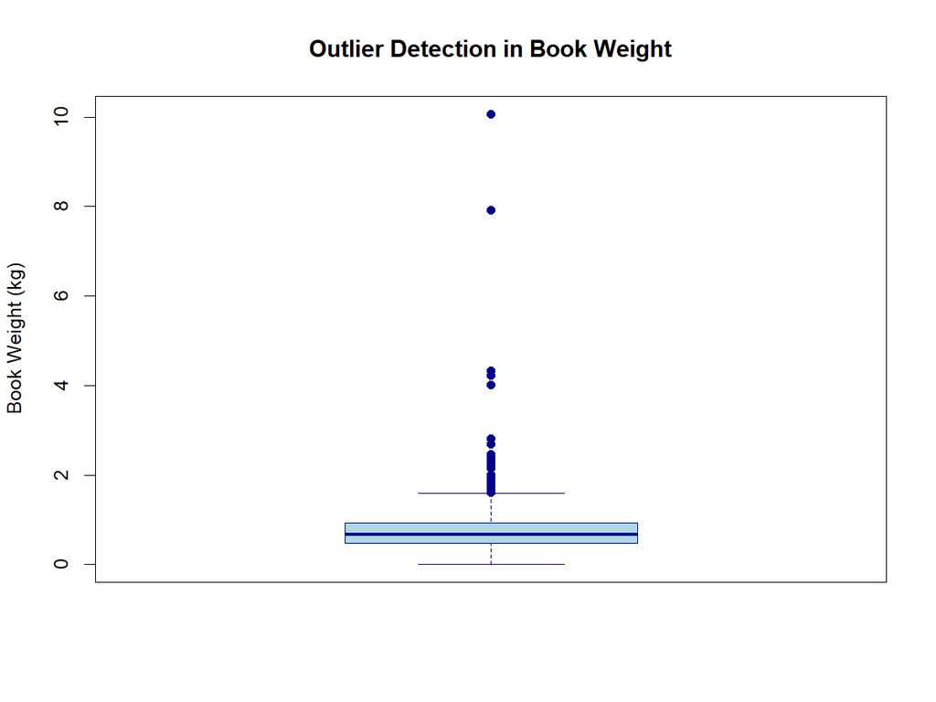

**4_1_histograms.png**

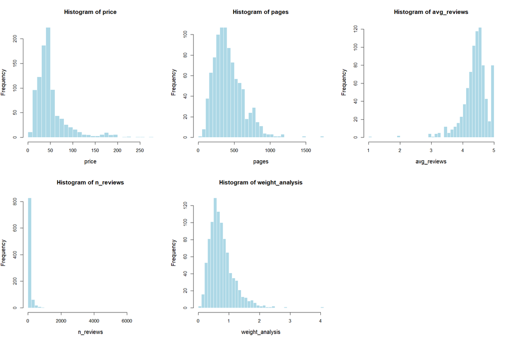

**4_2_boxplots.png**

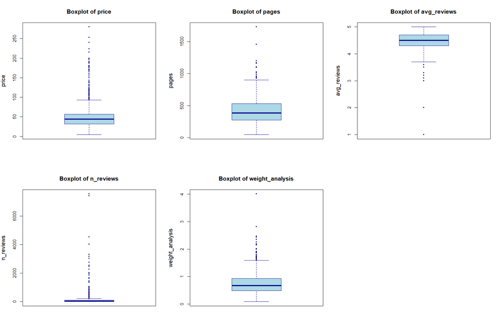

**4_3_log_reviews.png**

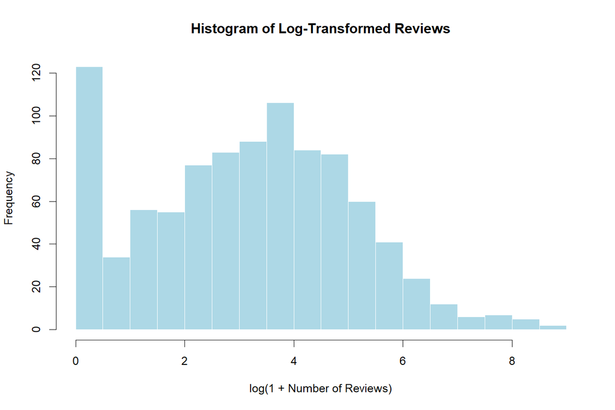

**4_4_star_ratings.png**

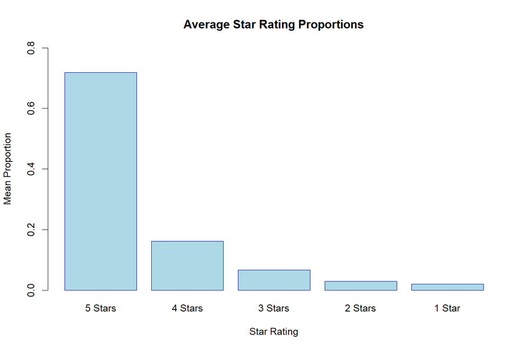

**4_5_pages_vs_price.png**

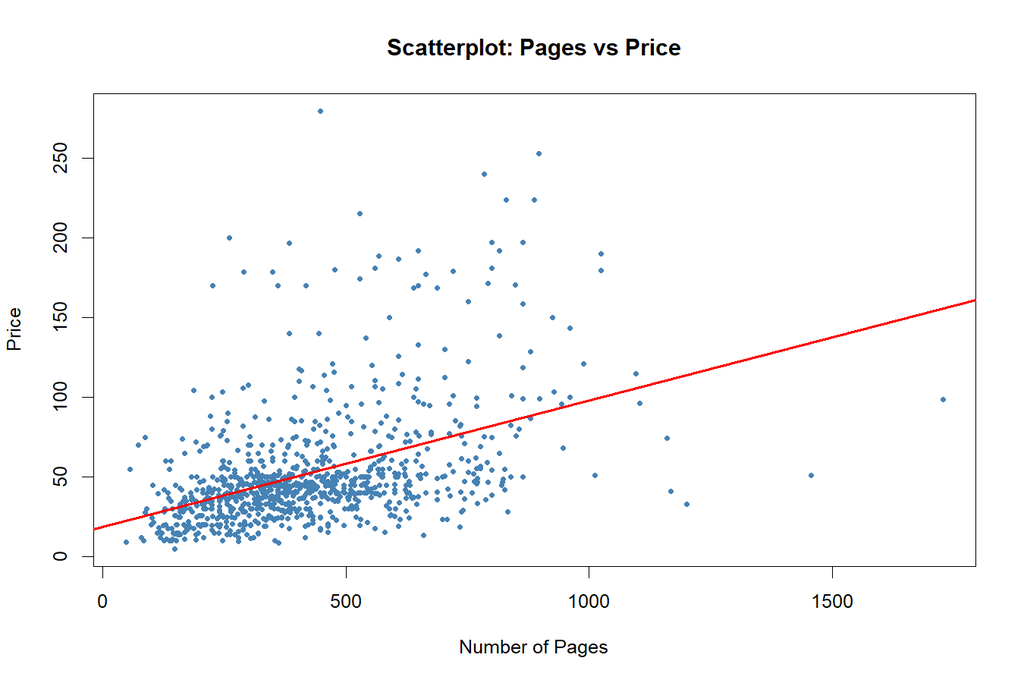

**4_6_pages_vs_weight.png**

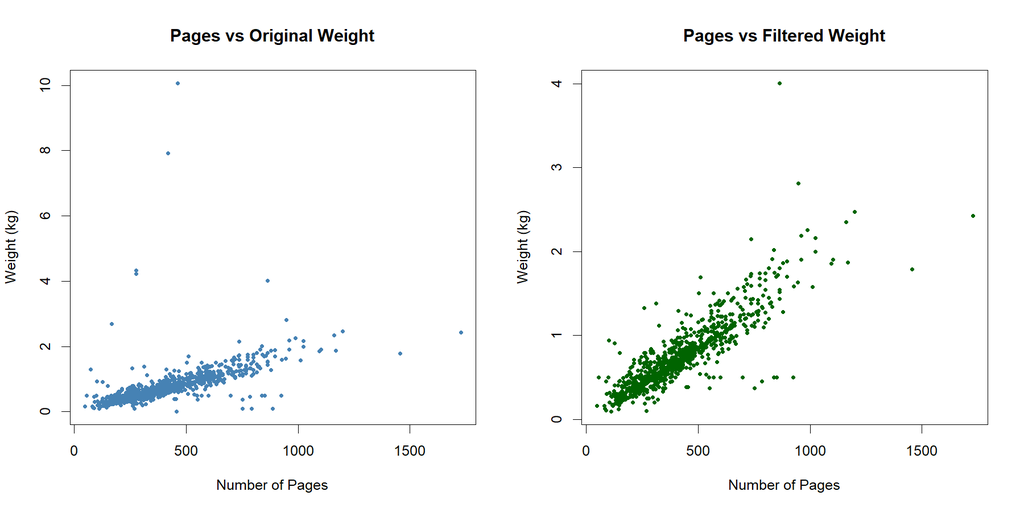

**4_7_reviews_vs_rating.png**

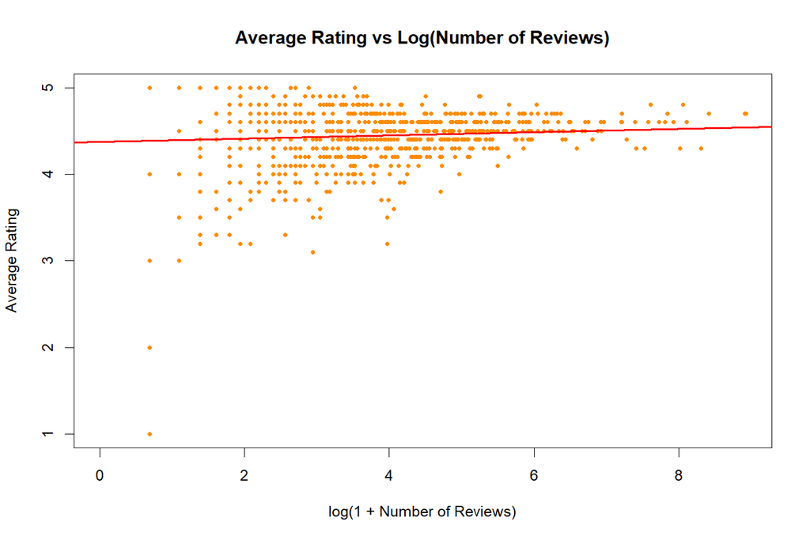

**all_numeric_boxplots.png**

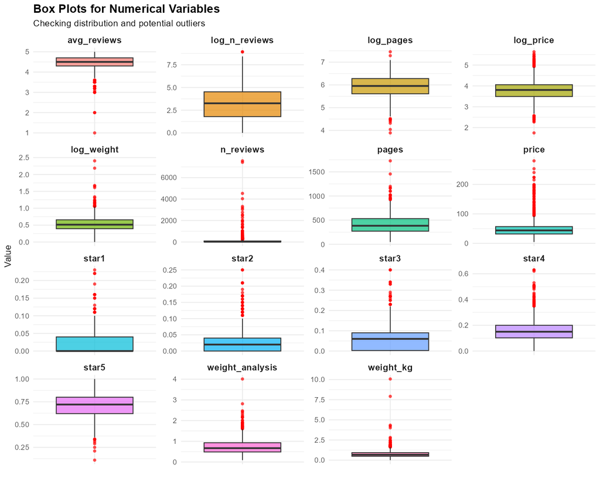

**categorical_bar_has_reviews.png**

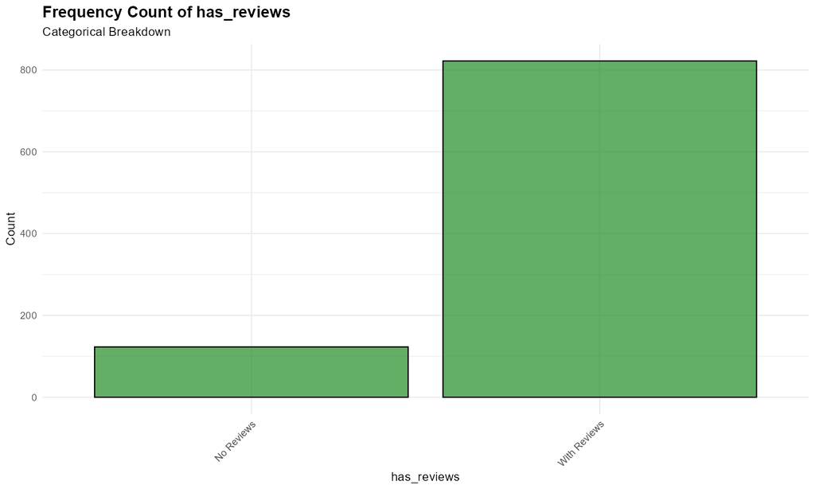

**categorical_bar_language.png**

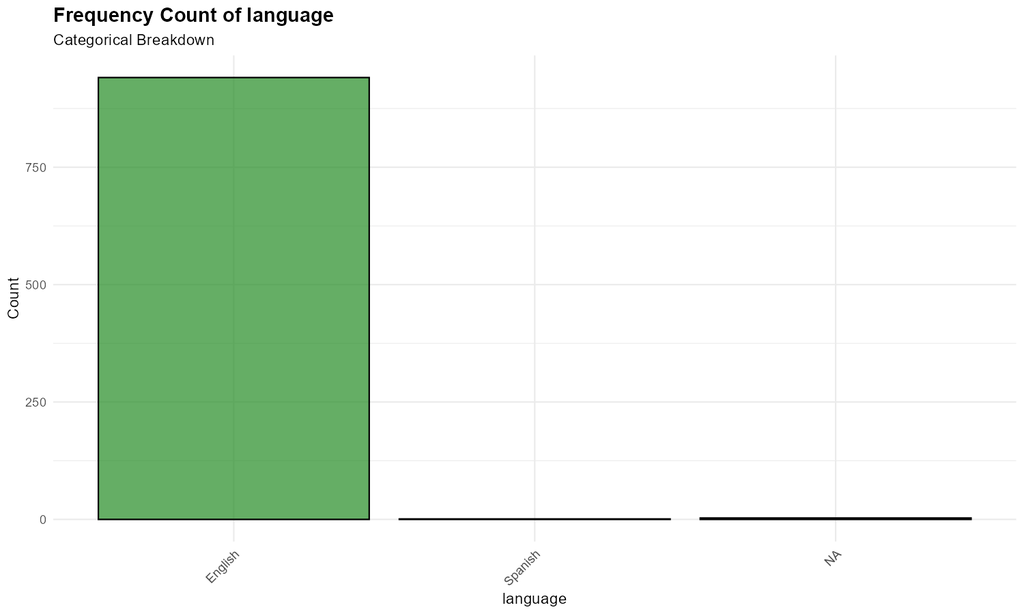

**correlation_matrix_basic.png**

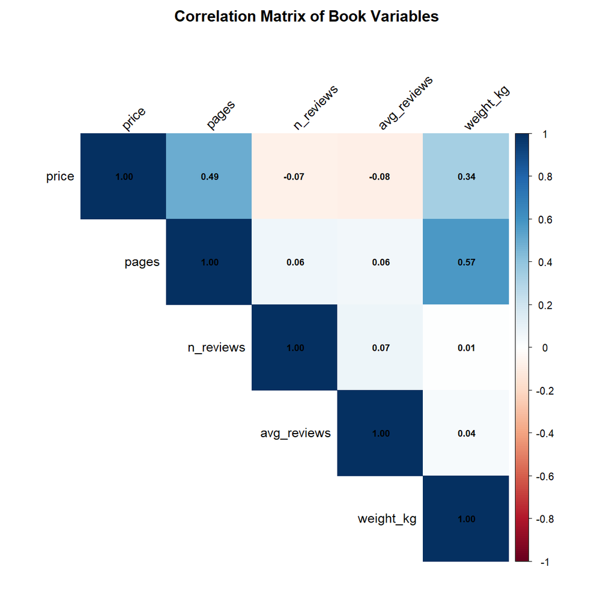

**correlation_matrix_heatmap.png**

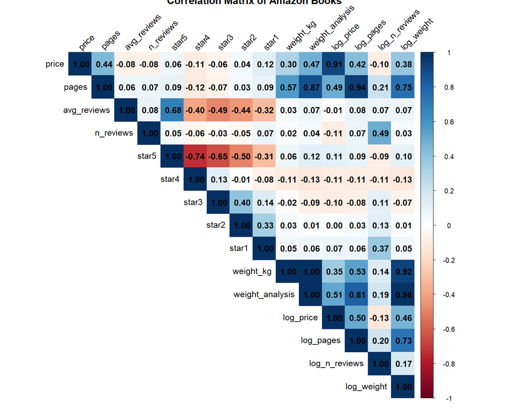

**distribution_avg_reviews.png**

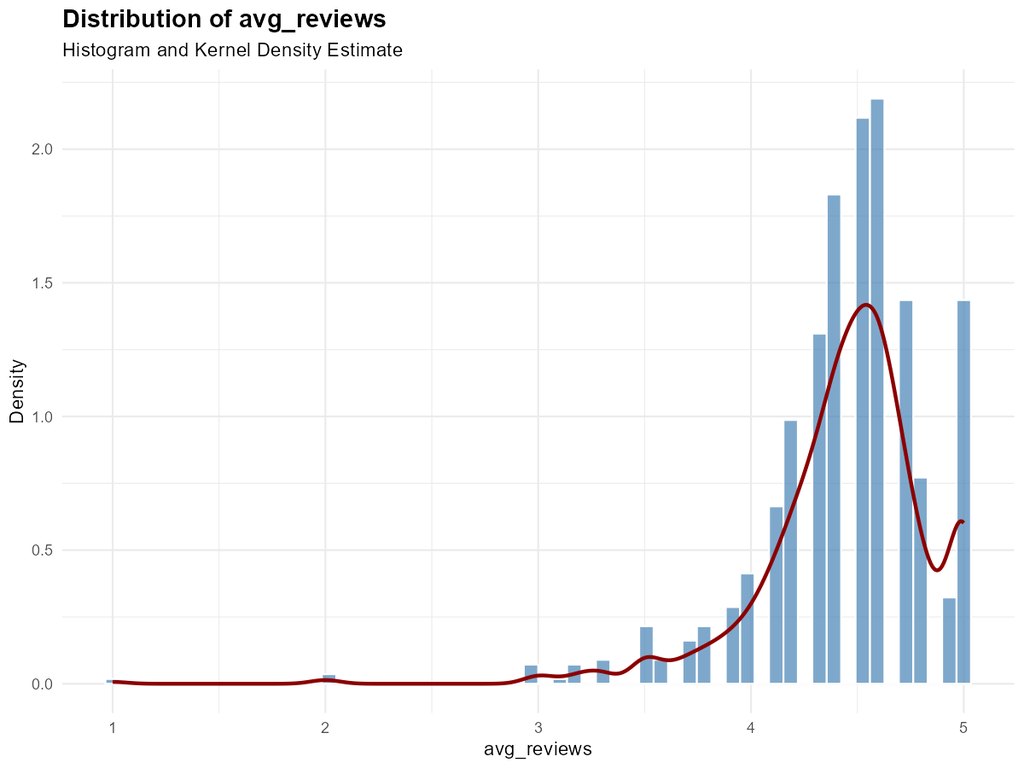

**distribution_log_n_reviews.png**

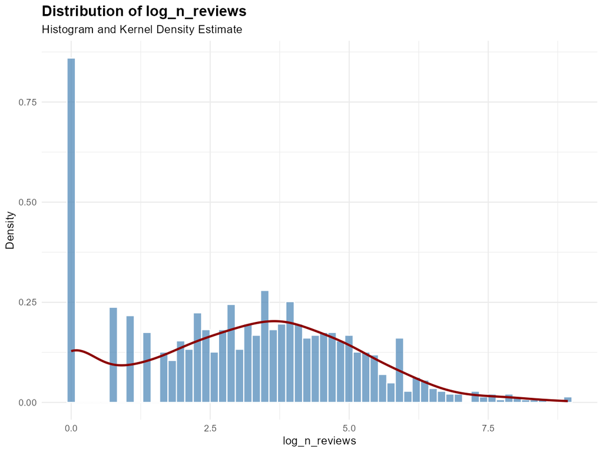

**distribution_log_pages.png**

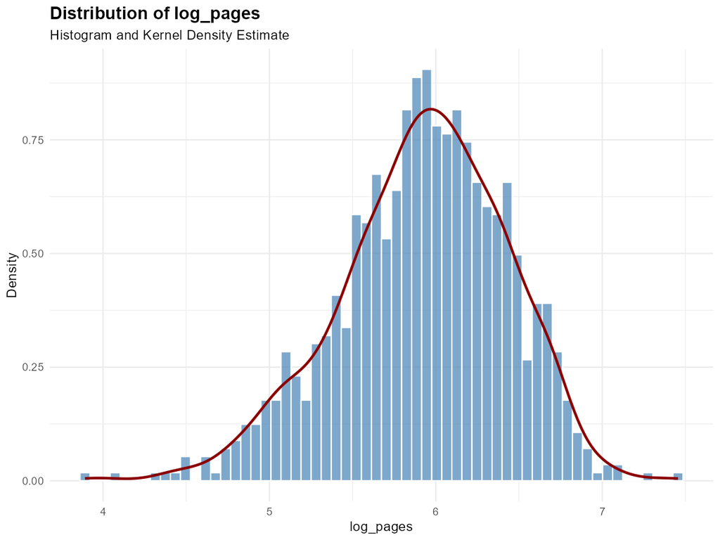

**distribution_log_price.png**

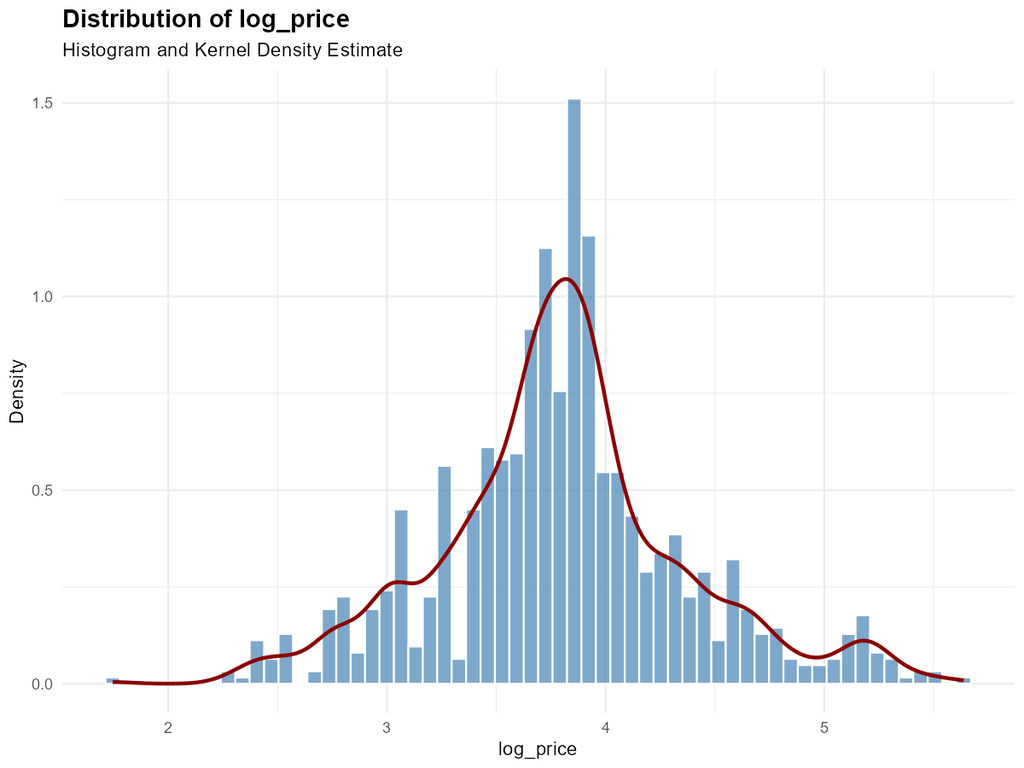

**distribution_log_weight.png**

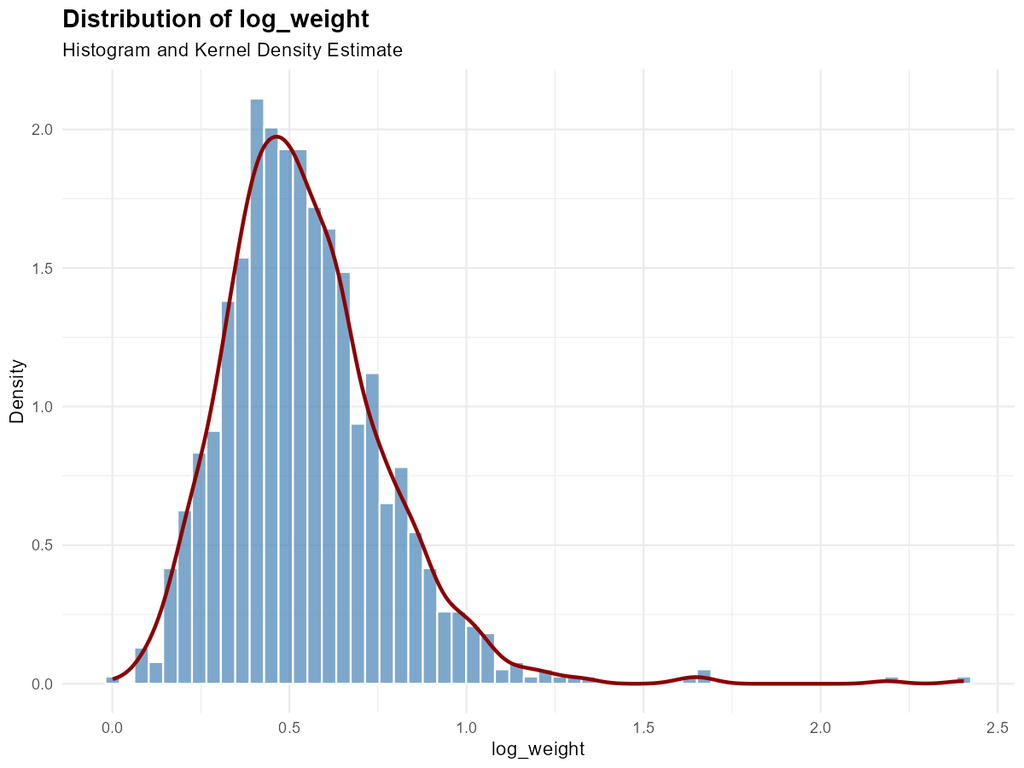

**distribution_n_reviews.png**

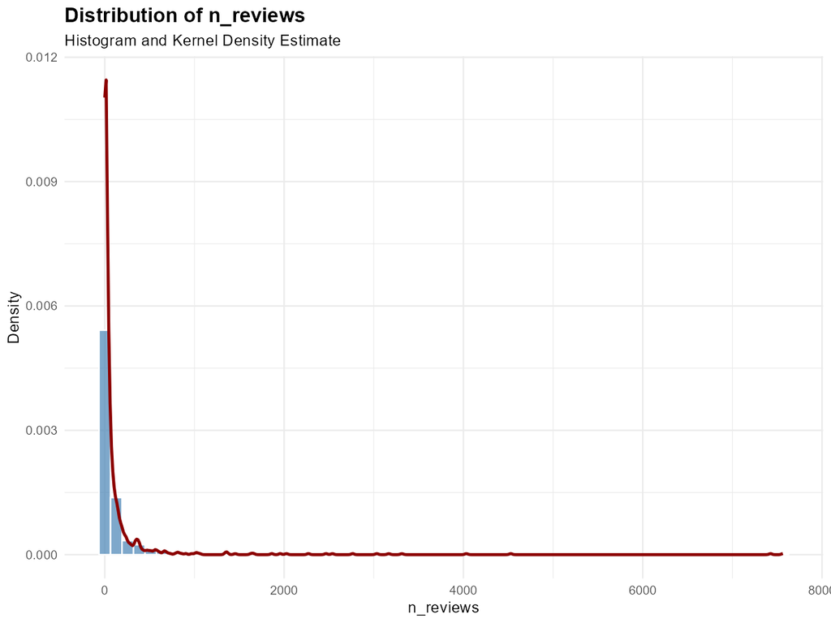

**distribution_pages.png**

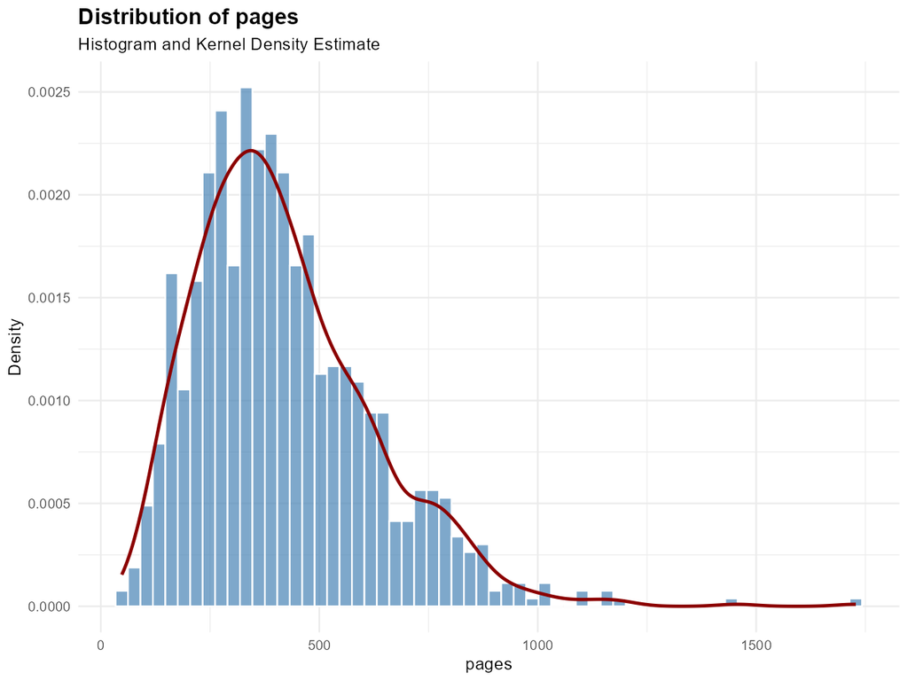

**distribution_price.png**

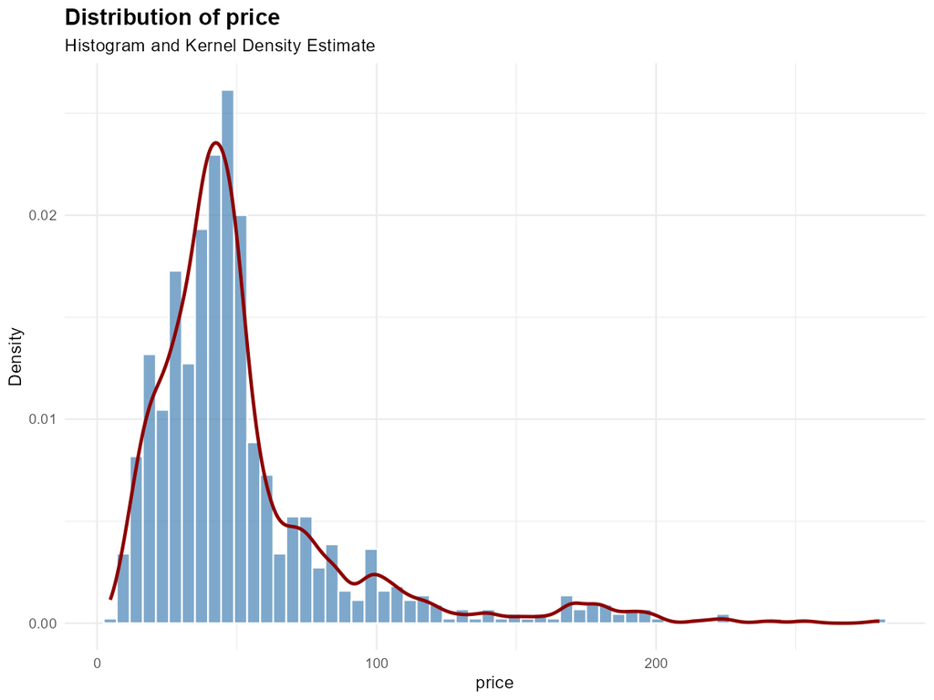

**distribution_star1.png**

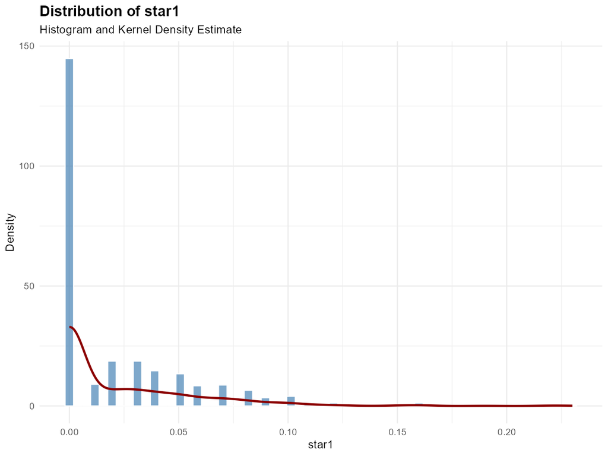

**distribution_star2.png**

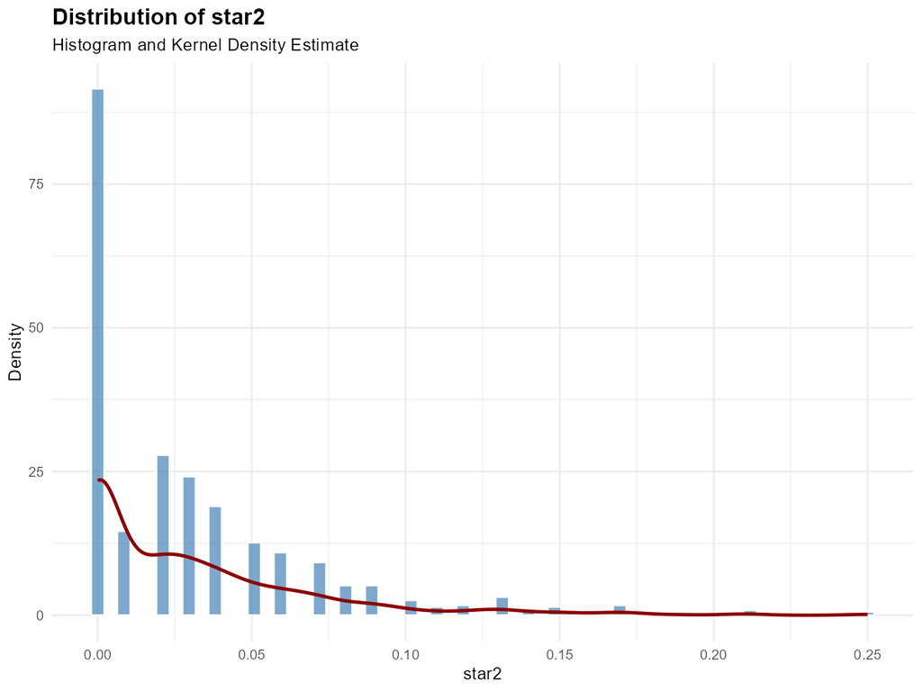

**distribution_star3.png**

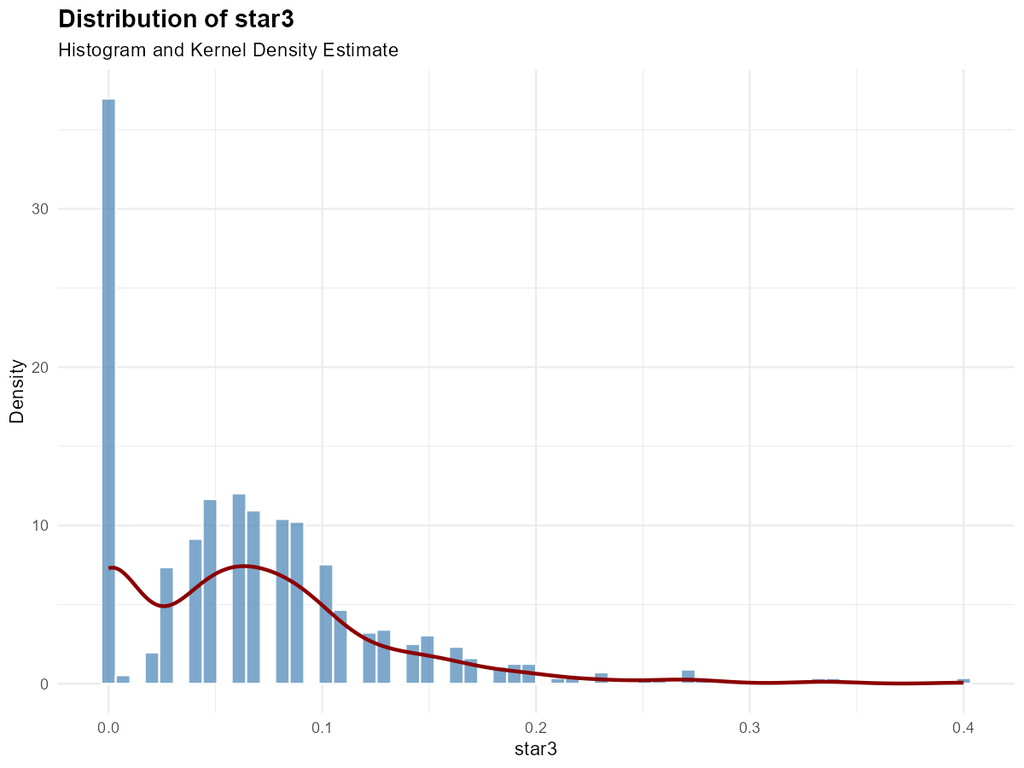

**distribution_star4.png**

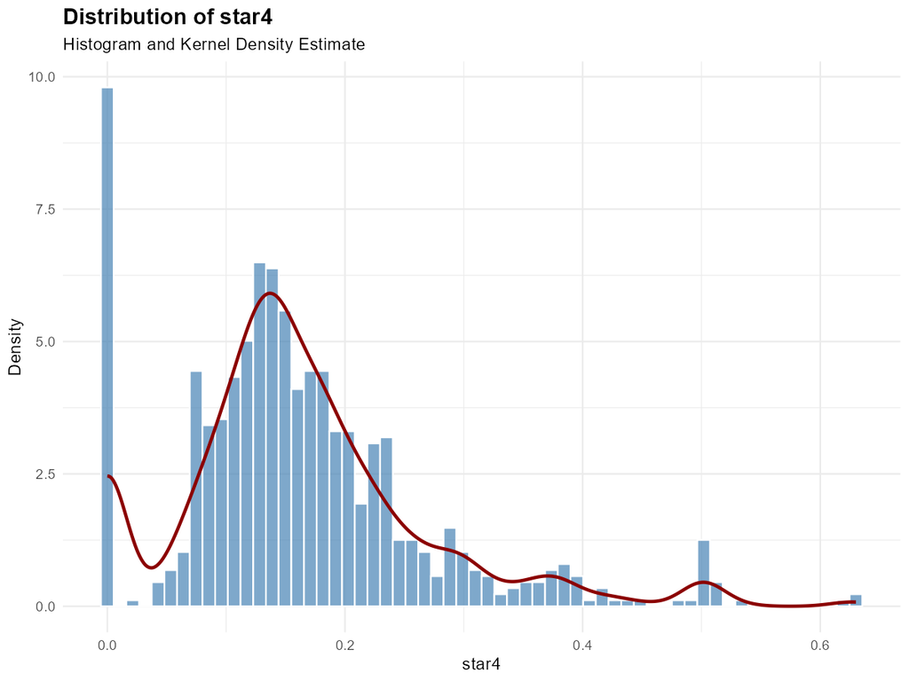

**distribution_star5.png**

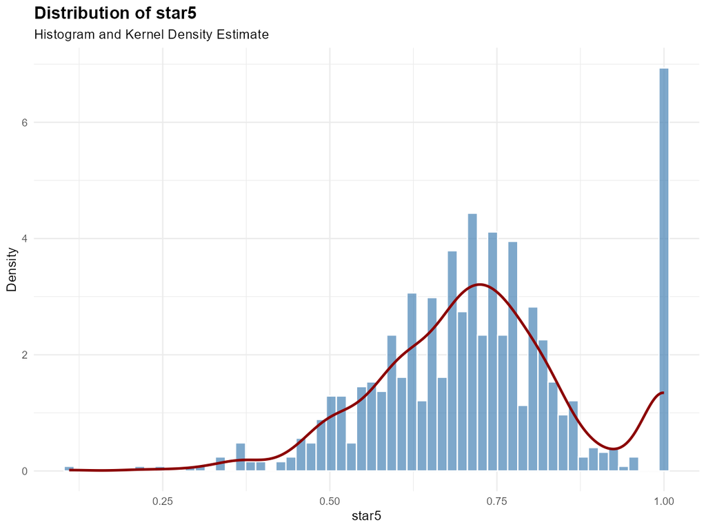

**distribution_weight_analysis.png**

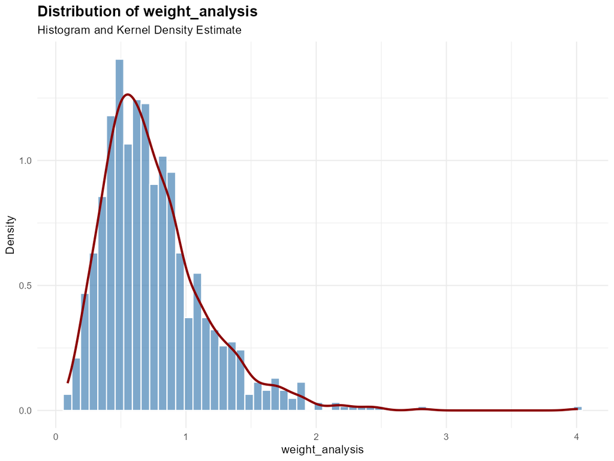

**distribution_weight_kg.png**

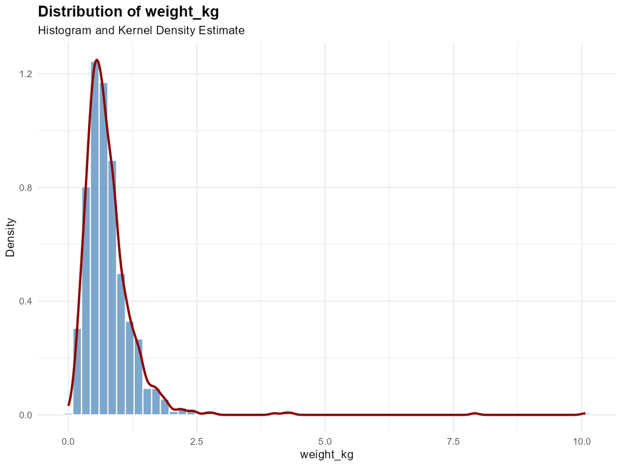